# [Data Analytics Framework](https://dataportal.daf.teamdigitale.it/#/) and Data processing

[figure not shown]

## Data carpentery Lab

#### Scuola Umbra di Amministrazione Pubblica - 2 agosto 2018

[figure not shown]

### Obiettivi:

- illustrare nuovi **strumenti e modalità** con cui **manipolare** i dati
- **processare** alcuni dataset attualmente pubblicati sul portale regionale umbro (Strutture ricettive e Codici attività)
- **metadatare** il nuovo dataset sulla piattaforma [DAF](https://dataportal.daf.teamdigitale.it/#/)
- **caricare** il dataset sulla piattafroma [DAF](https://dataportal.daf.teamdigitale.it/#/)
- **visualizzare** i dati inviati tramite i tool offerti dalla piattaforma DAF e sul portale [SaaS](https://umbria.daf.teamdigitale.it/)
- approfondire le **ontologia** interessate

[figure not shown]

## Strumenti:

### Anaconda

una distribuzione che contiene tutto ciò che ti serve

https://conda.io/miniconda.html

### Jupyter Notebook:

un ambiente di programmazione interattivo che ti permette di programmare direttamente dal tuo browser

http://jupyter.org/

### Pandas:

La libreria [Pandas](https://pandas.pydata.org/) fornisce strutture e strumenti per l'analisi di dati in linguaggio Python.

### Geo pandas:

La libreria per manipolare dati geografici

http://geopandas.org/gallery/create_geopandas_from_pandas.html#sphx-glr-gallery-create-geopandas-from-pandas-py

### Request

Per effettuare chiamate ad API

http://docs.python-requests.org/en/master/user/quickstart/

### Pysftp

Per utilizzare agilmente SFTP in python

http://pysftp.readthedocs.io/en/release_0.2.9/

## Risorse utili

- [Learn Python: the hard way](https://learnpythonthehardway.org/)
- [Pandas in 10 minuti](https://pandas.pydata.org/pandas-docs/stable/10min.html)
  - [video](https://vimeo.com/59324550)
- [Manuale Utente DAF](http://daf-dataportal.readthedocs.io/it/latest/)

## Dataset open data [Strutture ricettive](http://dati.umbria.it/dataset/strutture-ricettive)

[figure not shown]

Ultimo aggiornamento: Luglio 9, 2018

Creato Luglio 21, 2016

Formato CSV

[figure not shown]

### Importiamo la libreria Pandas

```python
import pandas as pd
```

```python
#suppress displaying long numbers in scientific notation
pd.set_option('display.float_format', lambda x: '%.2f' % x)
```

### Salviamo il contenuto di un dataset (URL) in un oggetto di tipo dataframe

```python
strutture = pd.read_csv("http://dati.umbria.it/datastore/dump/062d7bd6-f9c6-424e-9003-0b7cb3744cab")
```

### Visualizziamo il dataframe "strutture"

```python
strutture
```

|  | _id | ID | APT | COMUNE_CODICE | COMUNE | DENOMINAZIONE | TIPOLOGIA | CATEGORIA | INDIRIZZO | FRAZIONE | ... | TELEFONO | TELEFONO2 | FAX | WEB | EMAIL | COORDX | COORDY | TOTALE_UNITA | TOTALE_LETTI | TOTALE_BAGNI |
| --- | --- | --- | --- | --- | --- | --- | --- | --- | --- | --- | --- | --- | --- | --- | --- | --- | --- | --- | --- | --- | --- |
| 0 | 1 | 4945 | 2 | 54001 | ASSISI | OSTELLO FONTEMAGGIO | Ostello della gioventu' | Ostello della gioventu' | Via Eremo delle Carceri 24 | NaN | ... | 075813636 | 075812317 | 075813749 | www.fontemaggio.it | info@fontemaggio.it | 2327078.83 | 4770870.82 | 16 | 74 | 17 |
| 1 | 2 | 17481 | 2 | 54001 | ASSISI | A CASA DELLE FATE di Cannelli Lorena | Bed & Breakfast | Bed & Breakfast | Via Metastasio 24 | NaN | ... | 075813739 | 075816413 | NaN | www.casalefate.it | info@casalefate.it | nan | nan | 2 | 4 | 2 |
| 2 | 3 | 18660 | 2 | 54001 | ASSISI | A CASA MODESTINI di Vignoli Francesca | Bed & Breakfast | Bed & Breakfast | Via San Paolo 38 | NaN | ... | 3491930389 | 075812252 | 1782219813 | NaN | casamodestini@gmail.com | nan | nan | 1 | 3 | 1 |
| 3 | 4 | 18126 | 2 | 54001 | ASSISI | A CASA TUA di Mantovani Anna | Bed & Breakfast | Bed & Breakfast | Via Piaggia San Pietro 9 | NaN | ... | 075812987 | 329 7741497 | NaN | NaN | info.acasatua@yahoo.it | nan | nan | 2 | 3 | 2 |
| 4 | 5 | 13437 | 2 | 54001 | ASSISI | ADALGISA di Sensi Adalgisa | Bed & Breakfast | Bed & Breakfast | Via Lorenzo Perosi 33 | NaN | ... | 075813378 | NaN | NaN | NaN | agricola@nizzi.com | 2326766.01 | 4771047.31 | 1 | 2 | 1 |
| 5 | 6 | 9260 | 2 | 54001 | ASSISI | AGORA' | Centro soggiorno studi | Centro soggiorno studi | Voc. Le Case 42 | SANTA MARIA DI LIGNANO | ... | 075802261 | NaN | NaN | NaN | assisiresort1@gmail.com | 2333097.48 | 4777327.43 | 20 | 35 | 20 |
| 6 | 7 | 4948 | 2 | 54001 | ASSISI | AGRICOLA NIZZI | Agriturismo | 4 spighe | Costa di Trex 65 | COSTA DI TREX | ... | 075813378 | NaN | NaN | www.nizzi.com | agricola@nizzi.com | 2329234.54 | 4774594.87 | 6 | 28 | 6 |
| 7 | 8 | 9392 | 2 | 54001 | ASSISI | AGRITURISMO CASA NOCCHIA TOR DEI MAMMONI | Agriturismo | 2 spighe | Costa di Trex 7 | COSTA DI TREX | ... | 0758019025 | NaN | NaN | www.agriturismocasanocchia.it | info@agriturismocasanocchia.it | 2330306.72 | 4773159.98 | 4 | 10 | 4 |
| 8 | 9 | 4991 | 2 | 54001 | ASSISI | AGRITURISMO CASA NUOVA | Agriturismo | 2 spighe | Pian della Pieve 55 | NaN | ... | 075802143 | NaN | 075802143 | www.agriturismocasanuova.it | info@agriturismocasanuova.it | 2329929.06 | 4775384.03 | 5 | 10 | 5 |
| 9 | 10 | 5048 | 2 | 54001 | ASSISI | AGRITURISMO COL CACIONE | Agriturismo | 3 spighe | Costa di Trex | COSTA DI TREX | ... | 0758019010 | 3358352477 | 0758019010 | www.agriturismocolcacione.it | colcacione@gmail.com | 2330886.55 | 4773295.99 | 6 | 13 | 6 |
| 10 | 11 | 17160 | 2 | 54001 | ASSISI | AGRITURISMO DOLCE SENTIRE | Agriturismo | 2 spighe | Loc.Catecuccio 72 | PORZIANO | ... | 3396180265 | 3392232293 | NaN | www.agriturismodolcesentireassisi.it | info@agriturismodolcesentireassisi.it | nan | nan | 4 | 10 | 4 |
| 11 | 12 | 5018 | 2 | 54001 | ASSISI | AGRITURISMO IL CASTELLO | Agriturismo | 4 spighe | Costa di Trex 25 | COSTA DI TREX | ... | 075813683 | 3333282225 | 075813683 | www.agriturismoilcastello.com | info@agriturismoilcastello.com | 2329870.60 | 4773312.45 | 9 | 18 | 9 |
| 12 | 13 | 4975 | 2 | 54001 | ASSISI | AGRITURISMO IL GIRASOLE | Agriturismo | 2 spighe | Via Campiglione 2 | NaN | ... | 075813449 | 3471030526 | 075813449 | www.agriturismoilgirasole.net | info@agriturismoilgirasole.net | 2321257.34 | 4772124.77 | 5 | 10 | 5 |
| 13 | 14 | 5073 | 2 | 54001 | ASSISI | AGRITURISMO IL GROTTINO | Agriturismo | 2 spighe | Via Campiglione 26 | NaN | ... | 3779986054 | 3474799436 | NaN | NaN | agri.grottino@gmail.com | 2321257.34 | 4772124.77 | 6 | 10 | 4 |
| 14 | 15 | 5074 | 2 | 54001 | ASSISI | AGRITURISMO IL PODERE | Agriturismo | 5 spighe | Via Casa Madonna 14 | PETRIGNANO | ... | 0758038806 | 3312689221 | 0758038806 | www.agriturismoilpodere.com | agriturismoilpodereassisi@gmail.com | 2319532.99 | 4775286.41 | 5 | 10 | 5 |
| 15 | 16 | 5017 | 2 | 54001 | ASSISI | AGRITURISMO LA CANTINA | Agriturismo | 2 spighe | Via Campiglione,22 e Voc. S.Martino Via Vaiano... | NaN | ... | 075813386 | 3388553792 | 075813386 | www.agriturismolacantina.it | agri.lacantina@alice.it | 2322844.99 | 4772253.12 | 9 | 23 | 11 |
| 16 | 17 | 6646 | 2 | 54001 | ASSISI | AGRITURISMO LA MORA | Agriturismo | 3 spighe | Via Fonte Citerna 7 | SANTA MARIA DEGLI ANGELI | ... | 0758041164 | 3921248814 | 0758041164 | www.agriturismolamora.com | agriturismolamora@gmail.com | 2319089.32 | 4776785.14 | 11 | 29 | 10 |
| 17 | 18 | 18538 | 2 | 54001 | ASSISI | AGRITURISMO LA PALAZZETTA DI ASSISI | Agriturismo | 2 spighe | Via della Palazzetta | STERPETO | ... | 0758039223 | 0758038350 | NaN | www.agriturismolapalazzetta.com | info@agriturismolapalazzetta.com | nan | nan | 6 | 19 | 7 |
| 18 | 19 | 4976 | 2 | 54001 | ASSISI | AGRITURISMO LA PANORAMICA | Agriturismo | 2 spighe | Via Campiglione 6 | NaN | ... | 075813482 | 3397502248 | 075813482 | www.agriturismolapanoramica.it | info@agriturismolapanoramica.it | 2321257.34 | 4772124.77 | 8 | 20 | 9 |
| 19 | 20 | 4905 | 2 | 54001 | ASSISI | AGRITURISMO LA PIAGGIA | Agriturismo | 2 spighe | Viale Giovanna di Savoia 3 | NaN | ... | 3388894770 | 3388894770 | 075816231 | www.lapiaggia.it | info@lapiaggia.it | 2324937.76 | 4771743.07 | 6 | 12 | 6 |
| 20 | 21 | 6643 | 2 | 54001 | ASSISI | AGRITURISMO LA ROCCA | Agriturismo | 4 spighe | Rocca Sant' Angelo | ROCCA SANT'ANGELO | ... | 0758039289 | 3387050897 | NaN | www.agristar.it | info@agristar.it | 2320907.10 | 4778015.62 | 5 | 12 | 5 |
| 21 | 22 | 14547 | 2 | 54001 | ASSISI | AGRITURISMO LE CASE | Agriturismo | 3 spighe | Via Sanat Maria di Lignano - Voc. Le Case 42 | SANTA MARIA DI LIGNANO | ... | 075802431 | 3356760217 | NaN | www.lecase.biz | assisiresort1@gmail.com | 2333097.48 | 4777327.43 | 20 | 30 | 19 |
| 22 | 23 | 18218 | 2 | 54001 | ASSISI | AGRITURISMO LE SORGENTI | Agriturismo | 3 spighe | Loc. Paradiso 40 | NaN | ... | 0759976028 | 3347447841 | NaN | NaN | mar.stoppini@gmail.com | nan | nan | 3 | 10 | 3 |
| 23 | 24 | 5031 | 2 | 54001 | ASSISI | AGRITURISMO LONGETTI | Agriturismo | 4 spighe | Via Biagiano 35 | NaN | ... | 075816175 | NaN | 0759869562 | www.agriturismolongetti.com | webmaster@agriturismolongetti.com | 2324371.22 | 4774723.95 | 9 | 15 | 9 |
| 24 | 25 | 16622 | 2 | 54001 | ASSISI | AGRITURISMO PONTE ROSSO | Agriturismo | 1 spiga | Via Tescio 6 | SANTA MARIA DEGLI ANGELI | ... | 3392432883 | 0758001180 | NaN | NaN | info@assisium.com | nan | nan | 1 | 2 | 1 |
| 25 | 26 | 4897 | 2 | 54001 | ASSISI | AGRITURISMO SIENA | Agriturismo | 2 spighe | Via Della Pescara 11 | NaN | ... | 075813382 | NaN | NaN | NaN | NaN | 2326029.62 | 4771374.35 | 4 | 9 | 4 |
| 26 | 27 | 9925 | 2 | 54001 | ASSISI | AGRITURISMO SOLELUNA | Agriturismo | 1 spiga | Costa di Trex 54 | COSTA DI TREX | ... | 3471558278 | 3348509067 | 0758064506 | www.agriturismosoleluna.it | info@agriturismosoleluna.it | 2330640.27 | 4773009.24 | 6 | 23 | 7 |
| 27 | 28 | 18324 | 2 | 54001 | ASSISI | AL CASALE LA GERLA di Amicarelli Sara | Bed & Breakfast | Bed & Breakfast | Via Madre Terra 21 | NaN | ... | 3286286343 | 3333272965 | NaN | NaN | alcasalelagerla@libero.it | nan | nan | 3 | 7 | 3 |
| 28 | 29 | 13537 | 2 | 54001 | ASSISI | AL CASALINO di Caldari Gabriele | Bed & Breakfast | Bed & Breakfast | Via San Rufino 2 | NaN | ... | 3476123213 | NaN | NaN | www.alcasalino.it | alcasalino@alice.it | 2325880.82 | 4771475.66 | 1 | 2 | 1 |
| 29 | 30 | 9653 | 2 | 54001 | ASSISI | AL PIAN D'ASSISI di Alessandretti Simone | Bed & Breakfast | Bed & Breakfast | Via San Martino 14 | NaN | ... | 075816362 | 3391211850 | 075816362 | www.alpiandassisi.it | info@alpiandassisi.it | 2326029.62 | 4771374.35 | 4 | 7 | 4 |
| ... | ... | ... | ... | ... | ... | ... | ... | ... | ... | ... | ... | ... | ... | ... | ... | ... | ... | ... | ... | ... | ... |
| 4069 | 4070 | 8878 | 11 | 55032 | TERNI | PENNA ROSSA RANCH | Bed & Breakfast | Bed & Breakfast | Strada del Nocione 19 | SAN LIBERATORE | ... | 0744/62696 | 3387306148 | NaN | www.pennarossaranch.it | penna.rossa.ranch.bordoni@gmail.com | 2331629.09 | 4715943.45 | 2 | 6 | 2 |
| 4070 | 4071 | 8051 | 11 | 55032 | TERNI | PIEDIMONTE | Agriturismo | 1 spiga | Str. di S.Clemente 47 | NaN | ... | 0744/428277 | 3292979514 | NaN | NaN | susanna.santarelli@tiscali.it | 2327076.99 | 4717788.59 | 1 | 8 | 3 |
| 4071 | 4072 | 17925 | 11 | 55032 | TERNI | PISTELLI | Agriturismo | 1 spiga | Str. di Santa Maria Maddalena 24/E | NaN | ... | 338 6861898 | 0744283395 | 0744 283395 | NaN | info@frantoiopistelli.it | nan | nan | 5 | 9 | 5 |
| 4072 | 4073 | 10227 | 11 | 55032 | TERNI | RESIDENCE BIZZONI | Albergo | 3 stelle | V.le Carducci 10 | NaN | ... | 0744/44241 | NaN | 0744/4424222 | www.residencebizzoni.it | info@residencebizzoni.it | 2326429.98 | 4714911.46 | 14 | 36 | 16 |
| 4073 | 4074 | 14219 | 11 | 55032 | TERNI | RESIDENCE CARDINALE ALBORNOZ | Case e appartamenti per vacanze | Case e appartamenti per vacanze | Via dell'Ara Marina 3 | PIEDILUCO | ... | 0744/368550 | 3494496977 | 0744/368550 | NaN | residencealbornoz@tiscali.it | 2337616.57 | 4711848.04 | 7 | 14 | 7 |
| 4074 | 4075 | 18203 | 11 | 55032 | TERNI | RESIDENCE DIAMANTE ROSSO | Case e appartamenti per vacanze | Case e appartamenti per vacanze | Via Don Luigi Sturzo 9 | NaN | ... | 0744288220 | NaN | 0744226642 | www.residencediamanterosso.it | info@residencediamanterosso.it | nan | nan | 25 | 68 | 25 |
| 4075 | 4076 | 18889 | 11 | 55032 | TERNI | RESIDENCE VIVIVERDE | Case e appartamenti per vacanze | Case e appartamenti per vacanze | Via Angelo Rapaccioli 1 | NaN | ... | 3482412196 | 3341105096 | NaN | www.residenceviviverde.it | viviverdesrl@pec.it;info@residenceviviverde.it | nan | nan | 8 | 25 | 8 |
| 4076 | 4077 | 17073 | 11 | 55032 | TERNI | RESIDENZA CERQUETO | Ostello della gioventu' | Ostello della gioventu' | Via del Tordo 69-71 | NaN | ... | 0744303017 | 3475319624 | 0744404318 | www.residenzacerqueto.it | nardiarch@tiscali.it | nan | nan | 14 | 25 | 14 |
| 4077 | 4078 | 18952 | 11 | 55032 | TERNI | RESIDENZA GARIBALDI | Affittacamere | Affittacamere | Vico dei Tintori 9 | NaN | ... | 3486040064 | NaN | NaN | NaN | serenazampolini@gmail.com | nan | nan | 2 | 4 | 2 |
| 4078 | 4079 | 18447 | 11 | 55032 | TERNI | ROSSIEROSSI | Bed & Breakfast | Bed & Breakfast | Via Campofregoso 15/A | NaN | ... | 3467871699 | 0744814939 | NaN | NaN | rossierossibedandbreakfast@gmail.com | nan | nan | 3 | 6 | 2 |
| 4079 | 4080 | 17915 | 11 | 55032 | TERNI | VALLE DEGLI ULIVI | Bed & Breakfast | Bed & Breakfast | Str. di Collescipoli 173 | COLLESCIPOLI | ... | 3246271085 | NaN | 0744812609 | NaN | valledegliuliviterni@gmail.com | nan | nan | 2 | 4 | 2 |
| 4080 | 4081 | 14407 | 11 | 55032 | TERNI | VENTO TRA GLI ULIVI | Bed & Breakfast | Bed & Breakfast | Voc. San Bartolomeo 63 | NaN | ... | 3497168403 | 0744401493 | NaN | NaN | info@ventotragliulivi.com | 2330496.66 | 4717644.47 | 3 | 6 | 3 |
| 4081 | 4082 | 19673 | 11 | 55032 | TERNI | VILLA FLORIO | Affittacamere | Affittacamere | VIA MOLA DI BERNARDO 119 | NaN | ... | 3348077225 | 3285743703 | NaN | NaN | eugen.mano30@gmail.com | nan | nan | 1 | 2 | 1 |
| 4082 | 4083 | 17287 | 11 | 55032 | TERNI | VILLA LAURA RESIDENCE | Case e appartamenti per vacanze | Case e appartamenti per vacanze | Str. di Cospea 50 | NaN | ... | 3356699761 | 3355899150 | 0744815309 | www.villalauraresidence.it | info@villalauraresidence.it | nan | nan | 5 | 25 | 5 |
| 4083 | 4084 | 14149 | 11 | 55032 | TERNI | VILLA MAFALDA | Bed & Breakfast | Bed & Breakfast | Str. di Collescipoli 327 | COLLESCIPOLI | ... | 0744282456 | NaN | NaN | NaN | infovillamafalda@alice.it | 2324698.05 | 4712171.48 | 3 | 6 | 2 |
| 4084 | 4085 | 18742 | 11 | 55032 | TERNI | VILLA MARIANI | Affittacamere | Affittacamere | Strada di Perticara 38 | NaN | ... | 0744285343 | 3281654037 | NaN | NaN | lallolucia06@libero.it | nan | nan | 2 | 5 | 2 |
| 4085 | 4086 | 9624 | 11 | 55032 | TERNI | VILLA SABATINI | Bed & Breakfast | Bed & Breakfast | Via Faggeti 45 | MARMORE | ... | 0744/67103 | 3403321681-3482496100 | NaN | NaN | villasabatini_bb@yahoo.it | 2332529.27 | 4713161.40 | 3 | 8 | 3 |
| 4086 | 4087 | 17375 | 1 | 55033 | AVIGLIANO UMBRO | AGRITURISMO IL MANNELLO | Agriturismo | Agriturismo | Strada del Mannello | NaN | ... | 3293706302 | NaN | NaN | www.agriturismoilmannello.eu | info@agriturismoilmannello.eu | nan | nan | 1 | 8 | 4 |
| 4087 | 4088 | 19407 | 1 | 55033 | AVIGLIANO UMBRO | AGRITURISMO LA SELVA | Agriturismo | Agriturismo | Voc. Selva s.n.c. | NaN | ... | 335349678 | NaN | NaN | NaN | mariocarita@virgilio.it | nan | nan | 1 | 4 | 1 |
| 4088 | 4089 | 6707 | 1 | 55033 | AVIGLIANO UMBRO | AGRITURISMO PIANO GRANDE | Agriturismo | Agriturismo | Via Sant'Egidio 44 | NaN | ... | 0744933774 | 3357001575 | 0744441489 | NaN | agriturismopianogrande@virgilio.it | 2308997.53 | 4725760.50 | 6 | 20 | 9 |
| 4089 | 4090 | 17920 | 1 | 55033 | AVIGLIANO UMBRO | CASTELLO DI SISMANO | Residenza d'epoca | Residenza d'epoca | Via Corsini 12 | SISMANO | ... | 0744933416 | 3468549297 | NaN | www.sismano.com | info@sismano.com | nan | nan | 5 | 10 | 5 |
| 4090 | 4091 | 7757 | 1 | 55033 | AVIGLIANO UMBRO | HOTEL LA TENUTA DEI CICLAMINI | Albergo | 3 stelle | Localita' Casapancallo 3 | TOSCOLANO | ... | 074493431 | NaN | 0744935272 | www.iciclamini.it | daniela@cetmusic.it; | 2302835.34 | 4726356.19 | 58 | 145 | 64 |
| 4091 | 4092 | 15110 | 1 | 55033 | AVIGLIANO UMBRO | IL CALLAUZZO | Case e appartamenti per vacanze | Case e appartamenti per vacanze | Vocabolo Callauzzo 48-49A | SISMANO | ... | 0744933422 | NaN | NaN | NaN | NaN | 2310454.27 | 4729404.62 | 3 | 15 | 4 |
| 4092 | 4093 | 15704 | 1 | 55033 | AVIGLIANO UMBRO | L'ACQUAIO | Case e appartamenti per vacanze | Case e appartamenti per vacanze | Localita' Macchia dei Frati | NaN | ... | 07449343200 | NaN | 0744935277 | NaN | daniela@cetmusic.it | 2309140.02 | 4725331.00 | 3 | 10 | 3 |
| 4093 | 4094 | 15399 | 1 | 55033 | AVIGLIANO UMBRO | LA CRISTALLA | Agriturismo | Agriturismo | Vocabolo Cristalla 6 | SANTA RESTITUTA | ... | 0744935018 | 3336118410 | 0744935018 | NaN | NaN | 2302344.15 | 4724821.89 | 1 | 4 | 3 |
| 4094 | 4095 | 15108 | 1 | 55033 | AVIGLIANO UMBRO | LA FORTEZZA | Agriturismo | Agriturismo | Localita' Fortezza Alta 27 | DUNAROBBA | ... | 0744933515 | NaN | NaN | www.lafortezzaalta.com | info@lafortezzaalta.it | 2309681.72 | 4727686.78 | 4 | 19 | 5 |
| 4095 | 4096 | 18295 | 1 | 55033 | AVIGLIANO UMBRO | LA LANTERNA | Affittacamere | Affittacamere | Via Giacomo Matteotti 86 | NaN | ... | 0744933651 | 3337722239 | NaN | NaN | marsilianipietro@gmail.com | nan | nan | 6 | 12 | 6 |
| 4096 | 4097 | 18296 | 1 | 55033 | AVIGLIANO UMBRO | LA LANTERNA B & B | Bed & Breakfast | Bed & Breakfast | Via Giacomo Matteotti 86 | NaN | ... | 0744933651 | 3337722239 | NaN | NaN | marsilianipietro@gmail.com | nan | nan | 3 | 8 | 3 |
| 4097 | 4098 | 15333 | 1 | 55033 | AVIGLIANO UMBRO | LE BANDITE | Affittacamere | Affittacamere | Vocabolo Suffragio 5 | DUNAROBBA | ... | 07441980771 | 3339463097 | NaN | NaN | lebandite@alice.it | 2310351.66 | 4727135.38 | 4 | 12 | 4 |
| 4098 | 4099 | 15156 | 1 | 55033 | AVIGLIANO UMBRO | PIAN DELLE ROSE | Agriturismo | Agriturismo | Via Madonna delle Grazie 8 | NaN | ... | 0744933555 | 335212609 | 0744933555 | www.piandellerose.it | ciatticatozzi@alice.it; info@piandellerose.it | 2309111.96 | 4725307.06 | 3 | 10 | 3 |

4099 rows × 22 columns

Il comando *"read_csv()"* messo a disposizione di Pandas che è stato così smart da:

- interpretare correttamente il separatore di campo
- capire che la prima riga dentifica i nomi dei campi
- inferire correttamente il tipo di dato contenuto in ogni colonna

Il dataframe "*strutture"* può essere pensato come una tabella.

Ogni colonna della tabella è una "Series" di dati e può contenere un tipo di dato differente dalle altre.

[figure not shown]

# Ispezioniamo i dati

#### Che forma ha il nostro dataframe "strutture"?

```python
strutture.shape
```

```
(4099, 22)
```

Il nostro dataset è composto da:

- 4099 righe/strutture
- 22 colonne/attributi

#### Da quali Series/colonne è composto?

```python
strutture.columns
```

```
Index(['_id', 'ID', 'APT', 'COMUNE_CODICE', 'COMUNE', 'DENOMINAZIONE',
       'TIPOLOGIA', 'CATEGORIA', 'INDIRIZZO', 'FRAZIONE', 'CAP', 'PROV',
       'TELEFONO', 'TELEFONO2', 'FAX', 'WEB', 'EMAIL', 'COORDX', 'COORDY',
       'TOTALE_UNITA', 'TOTALE_LETTI', 'TOTALE_BAGNI'],
      dtype='object')
```

#### Di che tipo sono le Series/colonne che Pandas ha inferito automaticamente?

```python
strutture.dtypes
```

```
_id                int64
ID                 int64
APT                int64
COMUNE_CODICE      int64
COMUNE            object
DENOMINAZIONE     object
TIPOLOGIA         object
CATEGORIA         object
INDIRIZZO         object
FRAZIONE          object
CAP               object
PROV              object
TELEFONO          object
TELEFONO2         object
FAX               object
WEB               object
EMAIL             object
COORDX           float64
COORDY           float64
TOTALE_UNITA       int64
TOTALE_LETTI       int64
TOTALE_BAGNI       int64
dtype: object
```

#### Visualizza un'anteprima del dataset

```python
strutture.head(5)
```

|  | _id | ID | APT | COMUNE_CODICE | COMUNE | DENOMINAZIONE | TIPOLOGIA | CATEGORIA | INDIRIZZO | FRAZIONE | ... | TELEFONO | TELEFONO2 | FAX | WEB | EMAIL | COORDX | COORDY | TOTALE_UNITA | TOTALE_LETTI | TOTALE_BAGNI |
| --- | --- | --- | --- | --- | --- | --- | --- | --- | --- | --- | --- | --- | --- | --- | --- | --- | --- | --- | --- | --- | --- |
| 0 | 1 | 4945 | 2 | 54001 | ASSISI | OSTELLO FONTEMAGGIO | Ostello della gioventu' | Ostello della gioventu' | Via Eremo delle Carceri 24 | NaN | ... | 075813636 | 075812317 | 075813749 | www.fontemaggio.it | info@fontemaggio.it | 2327078.83 | 4770870.82 | 16 | 74 | 17 |
| 1 | 2 | 17481 | 2 | 54001 | ASSISI | A CASA DELLE FATE di Cannelli Lorena | Bed & Breakfast | Bed & Breakfast | Via Metastasio 24 | NaN | ... | 075813739 | 075816413 | NaN | www.casalefate.it | info@casalefate.it | nan | nan | 2 | 4 | 2 |
| 2 | 3 | 18660 | 2 | 54001 | ASSISI | A CASA MODESTINI di Vignoli Francesca | Bed & Breakfast | Bed & Breakfast | Via San Paolo 38 | NaN | ... | 3491930389 | 075812252 | 1782219813 | NaN | casamodestini@gmail.com | nan | nan | 1 | 3 | 1 |
| 3 | 4 | 18126 | 2 | 54001 | ASSISI | A CASA TUA di Mantovani Anna | Bed & Breakfast | Bed & Breakfast | Via Piaggia San Pietro 9 | NaN | ... | 075812987 | 329 7741497 | NaN | NaN | info.acasatua@yahoo.it | nan | nan | 2 | 3 | 2 |
| 4 | 5 | 13437 | 2 | 54001 | ASSISI | ADALGISA di Sensi Adalgisa | Bed & Breakfast | Bed & Breakfast | Via Lorenzo Perosi 33 | NaN | ... | 075813378 | NaN | NaN | NaN | agricola@nizzi.com | 2326766.01 | 4771047.31 | 1 | 2 | 1 |

5 rows × 22 columns

#### Qualità del dataset - Missing data

Pandas utilizza **NaN** per indicare quando un dato non è disponibile..

...By “missing” we simply mean NA (“not available”) or “not present for whatever reason”.

Many data sets simply arrive with missing data, either because it exists and was not collected or it never existed.

Consulta la [Documentazione](http://pandas.pydata.org/pandas-docs/stable/missing_data.html#working-with-missing-data)

```python
strutture.isnull().sum()
```

```
_id                 0
ID                  0
APT                 0
COMUNE_CODICE       0
COMUNE              0
DENOMINAZIONE       0
TIPOLOGIA           0
CATEGORIA           0
INDIRIZZO           0
FRAZIONE         2312
CAP                 0
PROV                0
TELEFONO            5
TELEFONO2        2041
FAX              2162
WEB              1394
EMAIL             191
COORDX           1564
COORDY           1564
TOTALE_UNITA        0
TOTALE_LETTI        0
TOTALE_BAGNI        0
dtype: int64
```

```python
strutture.isnull().sum().sum()
```

```
11233
```

#### Alcune statistiche descrittive

```python
strutture.describe()
```

|  | _id | ID | APT | COMUNE_CODICE | COORDX | COORDY | TOTALE_UNITA | TOTALE_LETTI | TOTALE_BAGNI |
| --- | --- | --- | --- | --- | --- | --- | --- | --- | --- |
| count | 4099.00 | 4099.00 | 4099.00 | 4099.00 | 2535.00 | 2535.00 | 4099.00 | 4099.00 | 4099.00 |
| mean | 2050.00 | 12909.66 | 6.38 | 54212.97 | 2311022.14 | 4762241.86 | 8.65 | 21.73 | 8.79 |
| std | 1183.42 | 5191.56 | 3.13 | 387.30 | 50737.35 | 98398.85 | 16.64 | 48.10 | 15.13 |
| min | 1.00 | 4780.00 | 1.00 | 54001.00 | 0.00 | 0.00 | 0.00 | 0.00 | 0.00 |
| 25% | 1025.50 | 7622.50 | 4.00 | 54014.00 | 2295177.65 | 4743371.28 | 2.00 | 6.00 | 2.00 |
| 50% | 2050.00 | 14475.00 | 6.00 | 54037.00 | 2312842.72 | 4768254.87 | 4.00 | 10.00 | 4.00 |
| 75% | 3074.50 | 18005.50 | 9.00 | 54053.00 | 2326787.87 | 4780571.43 | 8.00 | 23.00 | 9.00 |
| max | 4099.00 | 19700.00 | 12.00 | 55033.00 | 2373582.95 | 4828010.41 | 282.00 | 1220.00 | 245.00 |

#### Quali sono i valori e le frequenze che assume una colonne/series?

```python
strutture.COMUNE.value_counts()
```

```
ASSISI                      416
PERUGIA                     370
GUBBIO                      205
ORVIETO                     196
SPOLETO                     165
CASTIGLIONE DEL LAGO        163
FOLIGNO                     159
TODI                        115
CITTA' DI CASTELLO          105
MAGIONE                      92
UMBERTIDE                    89
TERNI                        83
SPELLO                       80
NORCIA                       72
MONTEFALCO                   64
AMELIA                       64
CITTA' DELLA PIEVE           62
MARSCIANO                    59
PASSIGNANO SUL TRASIMENO     58
BEVAGNA                      56
NARNI                        54
TUORO SUL TRASIMENO          50
VALFABBRICA                  48
PANICALE                     46
CORCIANO                     46
PIEGARO                      45
CASCIA                       42
TREVI                        42
GUALDO CATTANEO              41
BASTIA                       39
                           ...
AVIGLIANO UMBRO              13
CERRETO DI SPOLETO           12
CASTEL GIORGIO               12
MONTEGABBIONE                11
MONTECCHIO                   11
SCHEGGIA E PASCELUPO         10
COSTACCIARO                  10
SCHEGGINO                     9
CASTEL VISCARDO               9
VALLO DI NERA                 9
VALTOPINA                     9
SAN GEMINI                    9
CITERNA                       9
PENNA IN TEVERINA             8
PARRANO                       8
OTRICOLI                      7
GIOVE                         7
SANT'ANATOLIA DI NARCO        7
SIGILLO                       7
FRATTA TODINA                 7
MONTEFRANCO                   7
PORANO                        7
GUARDEA                       7
FOSSATO DI VICO               7
LUGNANO IN TEVERINA           7
ATTIGLIANO                    5
ALVIANO                       5
MONTELEONE DI SPOLETO         4
POLINO                        2
POGGIODOMO                    2
Name: COMUNE, Length: 92, dtype: int64
```

#### Filtrare il dataset per uno specifico valore all'interno di una colonna/Series

```python
strutture[strutture['COMUNE'] == "PANICALE"]
```

|  | _id | ID | APT | COMUNE_CODICE | COMUNE | DENOMINAZIONE | TIPOLOGIA | CATEGORIA | INDIRIZZO | FRAZIONE | ... | TELEFONO | TELEFONO2 | FAX | WEB | EMAIL | COORDX | COORDY | TOTALE_UNITA | TOTALE_LETTI | TOTALE_BAGNI |
| --- | --- | --- | --- | --- | --- | --- | --- | --- | --- | --- | --- | --- | --- | --- | --- | --- | --- | --- | --- | --- | --- |
| 2054 | 2053 | 5155 | 4 | 54037 | PANICALE | AGRITURISMO CERES | Agriturismo | 2 spighe | VIA DEI MANDORLI 25 | CASALINI | ... | 3333063304 | 3333063304 | 0662276682 | www.agriturismoceres.it | info@agriturismoceres.it | 2287490.07 | 4771556.99 | 6 | 24 | 9 |
| 2055 | 2054 | 15437 | 4 | 54037 | PANICALE | AGRITURISMO NELLA QUIETE DEL VERDE | Agriturismo | 1 spiga | VOC.FORNACE SECONDO 36 | NaN | ... | 0755003735 | 3483316096 | 0755003735 | www.nellaquietedelverde.com | brunocalzature@libero.it | 2282494.38 | 4761932.95 | 3 | 10 | 3 |
| 2056 | 2055 | 15249 | 4 | 54037 | PANICALE | ANGELI BIONDI | Agriturismo | Agriturismo | VIA XXV APRILE 15 | NaN | ... | 3391621661 | 0758355779 | NaN | NaN | angeli.biondi@alice.it | 2285167.64 | 4765864.07 | 1 | 3 | 1 |
| 2057 | 2056 | 17199 | 4 | 54037 | PANICALE | ANTICA CASA DEI FRATI | Affittacamere | Affittacamere | VIA ROMA 3 | NaN | ... | 3283343032 | 075833316 | 0758355549 | www.anticacasadeifrati.com | romizi@romizi.com | nan | nan | 1 | 6 | 2 |
| 2058 | 2057 | 5223 | 4 | 54037 | PANICALE | ANTICA POSTA DI BRACCIO | Case e appartamenti per vacanze | Case e appartamenti per vacanze | VIA TRASIMENO - BRACCIO 54 | NaN | ... | 0758350670 | 3356676889 | 0758350165 | www.anticaposta.it | info@anticaposta.it | 2286648.57 | 4773571.46 | 22 | 70 | 29 |
| 2059 | 2058 | 5145 | 4 | 54037 | PANICALE | AZIENDA AGRICOLA LA QUERCIOLANA | Agriturismo | 4 spighe | VIA VIENICHE 4 | NaN | ... | 075837477 | 3282196849 | NaN | www.laquerciolana.it | alessioquerciolana@tiscali.it | 2284859.90 | 4768458.93 | 5 | 21 | 8 |
| 2060 | 2059 | 5154 | 4 | 54037 | PANICALE | AZIENDA AGRICOLA POGGIO DI BRACCIO | Agriturismo | 3 spighe | POGGIO DI BRACCIO | NaN | ... | 0758350549 | NaN | NaN | NaN | r.beccali4@gmail.com | 2286929.44 | 4773686.00 | 4 | 20 | 9 |
| 2061 | 2060 | 5297 | 4 | 54037 | PANICALE | AZIENDA AGRITURISTICA MONTALI | Agriturismo | 2 spighe | VIA MONTALI 23 | NaN | ... | 0758350680 | 3357023591 | 0758350144 | www.montalionline.com | montali@montalionline.com | 2289532.04 | 4771902.66 | 10 | 25 | 10 |
| 2062 | 2061 | 14205 | 4 | 54037 | PANICALE | AZIENDA AGRITURISTICA OLDANI MARIA RAFFAELLA | Agriturismo | 4 spighe | VIA VIENICHE 13 | NaN | ... | 3201650167 | 3409271617 | NaN | www.poggiodelpero.it | info@vocabolopoggiodelpero.it | 2285607.39 | 4768177.12 | 3 | 15 | 4 |
| 2063 | 2062 | 9798 | 4 | 54037 | PANICALE | CASA BIANCONI | Affittacamere | Affittacamere | VIA DEL FILATOIO 24-26 | NaN | ... | 075837202 | NaN | 075837202 | www.casabianconi.com | mauriziobianconi@libero.it | 2283609.76 | 4768168.71 | 2 | 5 | 2 |
| 2064 | 2063 | 14258 | 4 | 54037 | PANICALE | CASALE FONTALLOGGIO | Agriturismo | 1 spiga | VOC. FONTALLOGGIO 20 | NaN | ... | 075837517 | 3384137242 | NaN | www.umbria-panicale.it | fontalloggio@yahoo.it | 2282854.15 | 4768743.57 | 4 | 8 | 4 |
| 2065 | 2064 | 7006 | 4 | 54037 | PANICALE | CASELLA DI PETERS HAIMO JOACHIM | Affittacamere | Affittacamere | VIA DEI MANDORLI -LOC. CASELLA 31 | CASALINI | ... | 0758350558 | 3473053501 | 0758350558 | NaN | haimodicerreto@netscape.net | 2289225.09 | 4770463.93 | 2 | 7 | 2 |
| 2066 | 2065 | 19615 | 4 | 54037 | PANICALE | CASETTA PASQUALINA | Bed & Breakfast | Bed & Breakfast | VIA GIORDANO BRUNO 24 | TAVERNELLE | ... | 3336186721 | 3281410625 | NaN | NaN | i27b@virgilio.it | nan | nan | 1 | 3 | 1 |
| 2067 | 2066 | 5203 | 4 | 54037 | PANICALE | CERRETO | Affittacamere | Affittacamere | VIA DEI MANDORLI 31 | CASALINI | ... | 0758350558 | 3473053501 | 0758350558 | NaN | haimodicerreto@netscape.net | 2289225.09 | 4770463.93 | 2 | 6 | 2 |
| 2068 | 2067 | 14375 | 4 | 54037 | PANICALE | I CASALI DI COLLE SAN PAOLO | Case e appartamenti per vacanze | Case e appartamenti per vacanze | VOC. FONTANELLE 11 | COLLE SAN PAOLO | ... | 075832030 | 3896433852 | NaN | www.collesanpaolo.it | casali@collesanpaolo.it | 2288870.91 | 4767719.51 | 5 | 19 | 7 |
| 2069 | 2068 | 13989 | 4 | 54037 | PANICALE | IL FIENILE | Agriturismo | 4 spighe | VIA CHIUSI - LOC. ACQUAVIVA 7 | NaN | ... | 075837502 | 3397256643 | 0759589222 | www.casavacanzeilfienile.it | casavacanzeilfienile@libero.it | 2282392.50 | 4768399.89 | 3 | 10 | 4 |
| 2070 | 2069 | 13432 | 4 | 54037 | PANICALE | IL PODERACCIO | Agriturismo | 3 spighe | VIA DEI MANDORLI 13/B | CASALINI | ... | 0758350700 | 3479612907 | NaN | www.poderacciohouse.com | poderaccio@libero.it | 2288584.49 | 4772034.97 | 3 | 7 | 2 |
| 2071 | 2070 | 9421 | 4 | 54037 | PANICALE | IL VECCHIO FRANTOIO | Affittacamere | Affittacamere | VIA VANNUCCI 29 | NaN | ... | 075837290 | 3475764343 | 075837290 | NaN | pjmarci@libero.it | 2283782.00 | 4768167.42 | 1 | 3 | 1 |
| 2072 | 2071 | 10391 | 4 | 54037 | PANICALE | LA CASINA DEL LILLOTATINI | Affittacamere | Affittacamere | VIA A.GROSSI 19 | NaN | ... | 075837771 | 3290764614 | NaN | NaN | vboldrini@libero.it | 2283621.13 | 4768176.77 | 1 | 2 | 1 |
| 2073 | 2072 | 15711 | 4 | 54037 | PANICALE | LA DIMORA DI ELISA | Bed & Breakfast | Bed & Breakfast | PIAZZA REGINA MARGHERITA 10 | NaN | ... | 075833316 | 3471089420 | 0758355549 | www.ladimoradielisa.com | stellenric@libero.it | 2283504.29 | 4768117.48 | 3 | 8 | 3 |
| 2074 | 2073 | 5261 | 4 | 54037 | PANICALE | LA FONTE DI SEPIACCI | Agriturismo | 4 spighe | LOC. MIGLIAIOLO - CAIOLO | NaN | ... | 075837737 | 3357753078 | 075837737 | www.agriturismolafonte.it | info@agriturismolafonte.it | 2284570.63 | 4767010.77 | 6 | 30 | 7 |
| 2075 | 2074 | 18185 | 4 | 54037 | PANICALE | LA LANTERNA | Agriturismo | 4 spighe | LOC. SIGNANO 43 | MISSIANO | ... | 3498048987 | 3279584070 | NaN | NaN | coppetticatia@virgilio.it | nan | nan | 7 | 22 | 7 |
| 2076 | 2075 | 16982 | 4 | 54037 | PANICALE | LA LUPAIA | Country house | Country house | VIA LE MURA 30 | NaN | ... | 0758378017 | NaN | 0758378017 | www.lalupaia.com | info@lalupaia.com | nan | nan | 7 | 18 | 7 |
| 2077 | 2076 | 6710 | 4 | 54037 | PANICALE | LA MEZZALUNA FRA LE MURA di CAPUCCINI LEONARDO | Agriturismo | 4 spighe | LE MURA - VIA PIAGGIOLA | NaN | ... | 0758378038 | 3496490355 | 0758378038 | www.mezzalunafralemura.com | info@mezzalunafralemura.com | 2284243.20 | 4768865.82 | 3 | 9 | 3 |
| 2078 | 2077 | 5332 | 4 | 54037 | PANICALE | LA PIAGGIOLA DEGLI OLIVI | Agriturismo | 3 spighe | VIA PIAGGIOLA - LOC. LE MURA 36 | NaN | ... | 075837775 | 075837300 | 075837300 | www.lapiaggioladegliolivi.com | info@lapiaggioladegliolivi.com | 2284270.27 | 4769049.13 | 3 | 12 | 4 |
| 2079 | 2078 | 14208 | 4 | 54037 | PANICALE | LA PIETRAIA | Case e appartamenti per vacanze | Case e appartamenti per vacanze | VIA GIOVETO 25 | NaN | ... | 075837380 | 3383904762 | NaN | www.lapietraia.net | stefano@panicale.org | 2282536.75 | 4768649.40 | 3 | 21 | 3 |
| 2080 | 2079 | 16365 | 4 | 54037 | PANICALE | LE CASETTE DI CEDROMONTE | Case e appartamenti per vacanze | Case e appartamenti per vacanze | VIA MOZART 4 | TAVERNELLE | ... | 3475724509 | 3284204325 | 0758352308 | www.lecasettedicedromonte.com | info@lecasettedicedromonte.com | 2287191.94 | 4766445.34 | 3 | 15 | 3 |
| 2081 | 2080 | 8794 | 4 | 54037 | PANICALE | MA.GI.A | Affittacamere | Affittacamere | VIA LE MURA 22 | NaN | ... | 051340630 | NaN | NaN | NaN | avvcesarini@icloud.com | 2285062.89 | 4769550.97 | 1 | 10 | 1 |
| 2082 | 2081 | 5239 | 4 | 54037 | PANICALE | MASOLINO | Albergo | 1 stella | VIA ROMA 7 | NaN | ... | 075837151 | 3282236912/3286239165 | NaN | www.masolino.it | info@masolino.it | 2283487.75 | 4768134.08 | 8 | 16 | 9 |
| 2083 | 2082 | 19374 | 4 | 54037 | PANICALE | MILLESOLI | Bed & Breakfast | Bed & Breakfast | VIA MAGIONACCIA 36 | NaN | ... | 3335930973 | NaN | NaN | NaN | millesoli@casalemillesoli.it | nan | nan | 3 | 6 | 3 |
| 2084 | 2083 | 15330 | 4 | 54037 | PANICALE | MOLINELLA | Case e appartamenti per vacanze | Case e appartamenti per vacanze | VOC. MOLINELLA 4 | COLLE SAN PAOLO | ... | 075832030 | 3896433852 | NaN | www.collesanpaolo.it | casali@collesanpaolo.it | 2318432.26 | 4734511.75 | 3 | 15 | 5 |
| 2085 | 2084 | 5171 | 4 | 54037 | PANICALE | MOLINO DA CAPO DI SCHMIDT ULLA | Affittacamere | Affittacamere | VIA MIGLIAIOLO 29 | NaN | ... | 075837481 | 3290268235 | NaN | NaN | ullaregina.schmidt@web.de | 2284540.63 | 4766700.99 | 1 | 4 | 2 |
| 2086 | 2085 | 5248 | 4 | 54037 | PANICALE | MONGIOVINO VECCHIO di DONATI GUERRIERI ETTORE | Agriturismo | Agriturismo | VIA MONGIOVINO VECCHIO 6 | MONGIOVINO | ... | 0758355311 | 3356276007 | 0758359497 | www.castellodimongiovino.com | info@castellodimongiovino.com | 2287063.73 | 4767215.11 | 4 | 23 | 5 |
| 2087 | 2086 | 18422 | 4 | 54037 | PANICALE | MONTALERA | Agriturismo | 3 spighe | VOC. CASELLE - STRADA VIC. DI MONTALERA 13 | CASALINI | ... | 0758350692 | 3333675035 | 0758350692 | NaN | agrimontalera@gmail.com | nan | nan | 2 | 8 | 4 |
| 2088 | 2087 | 7507 | 4 | 54037 | PANICALE | PIRA DEGIARDE' SILVANA | Agriturismo | Agriturismo | VOC. VIGNA PINO | NaN | ... | 075837168 | NaN | 075837168 | NaN | NaN | 2283740.40 | 4768177.25 | 3 | 18 | 6 |
| 2089 | 2088 | 15329 | 4 | 54037 | PANICALE | PODERACCIO | Agriturismo | Agriturismo | VOC. PODERACCIO 5 | COLLE SAN PAOLO | ... | 075832030 | 3291640990 | NaN | www.collesanpaolo.it | casali@collesanpaolo.it | 2280043.42 | 4768984.81 | 4 | 22 | 7 |
| 2090 | 2089 | 16897 | 4 | 54037 | PANICALE | PODERE MOLINACCIO | Bed & Breakfast | Bed & Breakfast | VOC. MOLINACCIO 18 | NaN | ... | 3483882447 | NaN | NaN | www.poderemolinaccio.it | info@poderemolinaccio.it | nan | nan | 3 | 6 | 3 |
| 2091 | 2090 | 7706 | 4 | 54037 | PANICALE | PODERE POGGIO SAN VITO | Agriturismo con area di sosta | 2 spighe | LOC. SANTA MARIA DELLE VOLPAIE 5 | NaN | ... | 075832726 | 3394517502 | 075832726 | www.poggiosanvito.it | poggiosanvito@libero.it | 2286002.06 | 4766075.64 | 6 | 29 | 5 |
| 2092 | 2091 | 6705 | 4 | 54037 | PANICALE | PODERINO CASELLO | Affittacamere | Affittacamere | VIA GRAMSCI 28 | NaN | ... | 075830449 | NaN | NaN | NaN | liarte@icloud.com | 2283358.34 | 4766888.80 | 2 | 6 | 2 |
| 2093 | 2092 | 15164 | 4 | 54037 | PANICALE | POGGIO DEI NOCI | Agriturismo | 2 spighe | LOC. CERVINAIA I 18 | MISSIANO | ... | 075832441 | NaN | 075832441 | NaN | riccionipaolo@libero.it; | 2283671.78 | 4765617.71 | 2 | 4 | 2 |
| 2094 | 2093 | 5143 | 4 | 54037 | PANICALE | TENUTA PATRIZIA LAMBORGHINI S.R.L. | Agriturismo | 4 spighe | LOC. SODERI 1 | NaN | ... | 0758350029 | NaN | 0758350029 | www.lamborghinionline.it | info@lamborghinionline.it | 2283821.78 | 4771195.82 | 12 | 30 | 12 |
| 2095 | 2094 | 19586 | 4 | 54037 | PANICALE | VILLA DI MISSIANO | Agriturismo | 3 spighe | LOC. MISSIANO | MISSIANO | ... | 3896843906 | 3287090747 | NaN | www.villadimissiano.it | info@villadimissiano.it | nan | nan | 6 | 16 | 6 |
| 2096 | 2095 | 5181 | 4 | 54037 | PANICALE | VILLA DI MONTESOLARE | Country house | Country house | VIA MONTALI - L0C.COLLE SAN PAOLO 7 | TAVERNELLE | ... | 075832376 | 0758355818 | 0758355462 | www.villamontesolare.com | info@villamontesolare.com | 2288643.96 | 4768822.01 | 28 | 65 | 28 |
| 2097 | 2096 | 17216 | 4 | 54037 | PANICALE | VILLA LA TORRE | Affittacamere | Affittacamere | VIA TRASIMENO 51 A | NaN | ... | 0758350546 | NaN | NaN | NaN | ccwinkle@hotmail.com | nan | nan | 1 | 4 | 1 |
| 2098 | 2097 | 7730 | 4 | 54037 | PANICALE | VILLA LE MURA | Residenza d'epoca | Residenza d'epoca | VIA LE MURA 1 | NaN | ... | 075837134 | 3485852528 | 075837134 | www.villalemura.com | vila.lemura.italy@gmail.com | 2284040.50 | 4768689.32 | 6 | 14 | 6 |
| 2099 | 2098 | 15077 | 4 | 54037 | PANICALE | VILLA REY | Country house | Country house | LOC. S.MARIA SECONDA 13 | NaN | ... | 0758352286 | NaN | 0758352287 | www.villarey.eu | info@villarey.eu | 2285872.44 | 4766336.17 | 6 | 18 | 7 |

46 rows × 22 columns

```python
strutture[(strutture['COMUNE'] == "ASSISI") & (strutture['TIPOLOGIA']=="Agriturismo")]
```

|  | _id | ID | APT | COMUNE_CODICE | COMUNE | DENOMINAZIONE | TIPOLOGIA | CATEGORIA | INDIRIZZO | FRAZIONE | ... | TELEFONO | TELEFONO2 | FAX | WEB | EMAIL | COORDX | COORDY | TOTALE_UNITA | TOTALE_LETTI | TOTALE_BAGNI |
| --- | --- | --- | --- | --- | --- | --- | --- | --- | --- | --- | --- | --- | --- | --- | --- | --- | --- | --- | --- | --- | --- |
| 6 | 7 | 4948 | 2 | 54001 | ASSISI | AGRICOLA NIZZI | Agriturismo | 4 spighe | Costa di Trex 65 | COSTA DI TREX | ... | 075813378 | NaN | NaN | www.nizzi.com | agricola@nizzi.com | 2329234.54 | 4774594.87 | 6 | 28 | 6 |
| 7 | 8 | 9392 | 2 | 54001 | ASSISI | AGRITURISMO CASA NOCCHIA TOR DEI MAMMONI | Agriturismo | 2 spighe | Costa di Trex 7 | COSTA DI TREX | ... | 0758019025 | NaN | NaN | www.agriturismocasanocchia.it | info@agriturismocasanocchia.it | 2330306.72 | 4773159.98 | 4 | 10 | 4 |
| 8 | 9 | 4991 | 2 | 54001 | ASSISI | AGRITURISMO CASA NUOVA | Agriturismo | 2 spighe | Pian della Pieve 55 | NaN | ... | 075802143 | NaN | 075802143 | www.agriturismocasanuova.it | info@agriturismocasanuova.it | 2329929.06 | 4775384.03 | 5 | 10 | 5 |
| 9 | 10 | 5048 | 2 | 54001 | ASSISI | AGRITURISMO COL CACIONE | Agriturismo | 3 spighe | Costa di Trex | COSTA DI TREX | ... | 0758019010 | 3358352477 | 0758019010 | www.agriturismocolcacione.it | colcacione@gmail.com | 2330886.55 | 4773295.99 | 6 | 13 | 6 |
| 10 | 11 | 17160 | 2 | 54001 | ASSISI | AGRITURISMO DOLCE SENTIRE | Agriturismo | 2 spighe | Loc.Catecuccio 72 | PORZIANO | ... | 3396180265 | 3392232293 | NaN | www.agriturismodolcesentireassisi.it | info@agriturismodolcesentireassisi.it | nan | nan | 4 | 10 | 4 |
| 11 | 12 | 5018 | 2 | 54001 | ASSISI | AGRITURISMO IL CASTELLO | Agriturismo | 4 spighe | Costa di Trex 25 | COSTA DI TREX | ... | 075813683 | 3333282225 | 075813683 | www.agriturismoilcastello.com | info@agriturismoilcastello.com | 2329870.60 | 4773312.45 | 9 | 18 | 9 |
| 12 | 13 | 4975 | 2 | 54001 | ASSISI | AGRITURISMO IL GIRASOLE | Agriturismo | 2 spighe | Via Campiglione 2 | NaN | ... | 075813449 | 3471030526 | 075813449 | www.agriturismoilgirasole.net | info@agriturismoilgirasole.net | 2321257.34 | 4772124.77 | 5 | 10 | 5 |
| 13 | 14 | 5073 | 2 | 54001 | ASSISI | AGRITURISMO IL GROTTINO | Agriturismo | 2 spighe | Via Campiglione 26 | NaN | ... | 3779986054 | 3474799436 | NaN | NaN | agri.grottino@gmail.com | 2321257.34 | 4772124.77 | 6 | 10 | 4 |
| 14 | 15 | 5074 | 2 | 54001 | ASSISI | AGRITURISMO IL PODERE | Agriturismo | 5 spighe | Via Casa Madonna 14 | PETRIGNANO | ... | 0758038806 | 3312689221 | 0758038806 | www.agriturismoilpodere.com | agriturismoilpodereassisi@gmail.com | 2319532.99 | 4775286.41 | 5 | 10 | 5 |
| 15 | 16 | 5017 | 2 | 54001 | ASSISI | AGRITURISMO LA CANTINA | Agriturismo | 2 spighe | Via Campiglione,22 e Voc. S.Martino Via Vaiano... | NaN | ... | 075813386 | 3388553792 | 075813386 | www.agriturismolacantina.it | agri.lacantina@alice.it | 2322844.99 | 4772253.12 | 9 | 23 | 11 |
| 16 | 17 | 6646 | 2 | 54001 | ASSISI | AGRITURISMO LA MORA | Agriturismo | 3 spighe | Via Fonte Citerna 7 | SANTA MARIA DEGLI ANGELI | ... | 0758041164 | 3921248814 | 0758041164 | www.agriturismolamora.com | agriturismolamora@gmail.com | 2319089.32 | 4776785.14 | 11 | 29 | 10 |
| 17 | 18 | 18538 | 2 | 54001 | ASSISI | AGRITURISMO LA PALAZZETTA DI ASSISI | Agriturismo | 2 spighe | Via della Palazzetta | STERPETO | ... | 0758039223 | 0758038350 | NaN | www.agriturismolapalazzetta.com | info@agriturismolapalazzetta.com | nan | nan | 6 | 19 | 7 |
| 18 | 19 | 4976 | 2 | 54001 | ASSISI | AGRITURISMO LA PANORAMICA | Agriturismo | 2 spighe | Via Campiglione 6 | NaN | ... | 075813482 | 3397502248 | 075813482 | www.agriturismolapanoramica.it | info@agriturismolapanoramica.it | 2321257.34 | 4772124.77 | 8 | 20 | 9 |
| 19 | 20 | 4905 | 2 | 54001 | ASSISI | AGRITURISMO LA PIAGGIA | Agriturismo | 2 spighe | Viale Giovanna di Savoia 3 | NaN | ... | 3388894770 | 3388894770 | 075816231 | www.lapiaggia.it | info@lapiaggia.it | 2324937.76 | 4771743.07 | 6 | 12 | 6 |
| 20 | 21 | 6643 | 2 | 54001 | ASSISI | AGRITURISMO LA ROCCA | Agriturismo | 4 spighe | Rocca Sant' Angelo | ROCCA SANT'ANGELO | ... | 0758039289 | 3387050897 | NaN | www.agristar.it | info@agristar.it | 2320907.10 | 4778015.62 | 5 | 12 | 5 |
| 21 | 22 | 14547 | 2 | 54001 | ASSISI | AGRITURISMO LE CASE | Agriturismo | 3 spighe | Via Sanat Maria di Lignano - Voc. Le Case 42 | SANTA MARIA DI LIGNANO | ... | 075802431 | 3356760217 | NaN | www.lecase.biz | assisiresort1@gmail.com | 2333097.48 | 4777327.43 | 20 | 30 | 19 |
| 22 | 23 | 18218 | 2 | 54001 | ASSISI | AGRITURISMO LE SORGENTI | Agriturismo | 3 spighe | Loc. Paradiso 40 | NaN | ... | 0759976028 | 3347447841 | NaN | NaN | mar.stoppini@gmail.com | nan | nan | 3 | 10 | 3 |
| 23 | 24 | 5031 | 2 | 54001 | ASSISI | AGRITURISMO LONGETTI | Agriturismo | 4 spighe | Via Biagiano 35 | NaN | ... | 075816175 | NaN | 0759869562 | www.agriturismolongetti.com | webmaster@agriturismolongetti.com | 2324371.22 | 4774723.95 | 9 | 15 | 9 |
| 24 | 25 | 16622 | 2 | 54001 | ASSISI | AGRITURISMO PONTE ROSSO | Agriturismo | 1 spiga | Via Tescio 6 | SANTA MARIA DEGLI ANGELI | ... | 3392432883 | 0758001180 | NaN | NaN | info@assisium.com | nan | nan | 1 | 2 | 1 |
| 25 | 26 | 4897 | 2 | 54001 | ASSISI | AGRITURISMO SIENA | Agriturismo | 2 spighe | Via Della Pescara 11 | NaN | ... | 075813382 | NaN | NaN | NaN | NaN | 2326029.62 | 4771374.35 | 4 | 9 | 4 |
| 26 | 27 | 9925 | 2 | 54001 | ASSISI | AGRITURISMO SOLELUNA | Agriturismo | 1 spiga | Costa di Trex 54 | COSTA DI TREX | ... | 3471558278 | 3348509067 | 0758064506 | www.agriturismosoleluna.it | info@agriturismosoleluna.it | 2330640.27 | 4773009.24 | 6 | 23 | 7 |
| 34 | 35 | 8884 | 2 | 54001 | ASSISI | ALLA MADONNA DEL PIATTO | Agriturismo | 2 spighe | Via Petrata 37 | PIEVE SAN NICOLO' | ... | 0758199050 | 3287025297 | NaN | www.madonnadelpiatto.com | madonnadp@gmail.com | 2324494.46 | 4773433.98 | 7 | 16 | 8 |
| 39 | 40 | 17634 | 2 | 54001 | ASSISI | ANTICA FONTE | Agriturismo | 2 spighe | Via Petrata 1 | NaN | ... | 075816065 | 3496365463 | NaN | www.anticafonteassisi.com | info@anticafonteassisi.com | nan | nan | 4 | 10 | 4 |
| 52 | 53 | 16623 | 2 | 54001 | ASSISI | ASSISIUM | Agriturismo | 1 spiga | Via Tescio 6 | SANTA MARIA DEGLI ANGELI | ... | 3392432883 | 0758043305 | NaN | www.assisium.com | info@assisium.com | nan | nan | 11 | 22 | 11 |
| 55 | 56 | 17844 | 2 | 54001 | ASSISI | AZIENDA AGRARIA PARADISO 44 | Agriturismo | 3 spighe | Paradiso - Voc.Trittello 44 | NaN | ... | 0759975740 | 3315021674 | NaN | www.paradiso44.com | info@paradiso44.com | nan | nan | 4 | 8 | 4 |
| 56 | 57 | 7220 | 2 | 54001 | ASSISI | AZIENDA AGRITURISTICA - RESIDENZA OASI BATTIFO... | Agriturismo | 4 spighe | Voc. Battifoglia - Paradiso 33 | NaN | ... | 075802320 | NaN | 075802320 | www.oasibattifoglia.com | info@oasibattifoglia.com | 2326336.49 | 4770941.56 | 6 | 20 | 8 |
| 57 | 58 | 9834 | 2 | 54001 | ASSISI | AZIENDA AGRITURISTICA TORDONI DANIELA | Agriturismo | 4 spighe | Via del Paduletto | CAPODACQUA | ... | 0758065810 | NaN | 0758064986 | NaN | info@valledelsubasio.it | 2326865.23 | 4767384.37 | 15 | 30 | 15 |
| 78 | 78 | 18663 | 2 | 54001 | ASSISI | BASALETTO | Agriturismo | 3 spighe | Loc. Basaletto snc | NaN | ... | 3296198360 | 3487908375 | NaN | www.basaletto.it | info@basaletto.it | nan | nan | 5 | 10 | 5 |
| 81 | 81 | 7996 | 2 | 54001 | ASSISI | BORGO COLDERBA | Agriturismo | 3 spighe | Via della Passerella 1 | NaN | ... | 075816809 | 3397874812 | 051300038 | www.borgocolderba.com | anthea.boynton@gmail.com | 2323836.34 | 4772066.28 | 3 | 10 | 3 |
| 83 | 83 | 9835 | 2 | 54001 | ASSISI | BORRINI FRANCESCA | Agriturismo | 2 spighe | Via di Mezzo 46 | RIVOTORTO | ... | 3473127784 | 3931560708 | NaN | www.agriturismoborrini.it | info@agriturismoborrini.it | 2326753.64 | 4768463.75 | 5 | 10 | 5 |
| ... | ... | ... | ... | ... | ... | ... | ... | ... | ... | ... | ... | ... | ... | ... | ... | ... | ... | ... | ... | ... | ... |
| 287 | 288 | 5029 | 2 | 54001 | ASSISI | LA PIEVE | Agriturismo | 4 spighe | Pieve S. Nicolò 17 | PIEVE SAN NICOLO' | ... | 0758199018 | NaN | 0758199018 | NaN | segreteria@agriturismolapieve.com | 2325802.83 | 4775974.58 | 8 | 16 | 8 |
| 289 | 290 | 9899 | 2 | 54001 | ASSISI | LA ROCCHICCIOLA DELLE UPUPE | Agriturismo | 3 spighe | Via Eremo delle Carceri 15 | NaN | ... | 3282572926 | NaN | NaN | www.larocchiccioladelleupupe.com | giovanna.vitacchiano@gmail.com | 2326241.43 | 4771359.38 | 1 | 8 | 2 |
| 292 | 293 | 14076 | 2 | 54001 | ASSISI | LA TAVOLA DEI CAVALIERI | Agriturismo | 4 spighe | Santa Maria di Lignano Loc.Satriano 104 | ARMENZANO | ... | 0758019054 | NaN | 0759480298 | www.cavalieri.mobi | latavolaborgo@gmail.com | 2326248.01 | 4772394.75 | 10 | 20 | 10 |
| 297 | 298 | 17029 | 2 | 54001 | ASSISI | LE VAGLIE | Agriturismo | 2 spighe | Pieve San Nicolò | NaN | ... | 0758199018 | 3338178150 | 0758199018 | NaN | NaN | nan | nan | 13 | 16 | 13 |
| 303 | 304 | 5061 | 2 | 54001 | ASSISI | LE COLOMBE | Agriturismo | 5 spighe | Rocca Sant'Angelo 42/43 | ROCCA SANT'ANGELO | ... | 0758098101 | NaN | NaN | www.lecolombe.com | info@lecolombe.com | 2321041.91 | 4778110.06 | 8 | 29 | 8 |
| 304 | 305 | 11007 | 2 | 54001 | ASSISI | LE DIMORE DI SAN CRISPINO RESORT E SPA | Agriturismo | 5 spighe | Voc. Reale 129 | TORDANDREA | ... | 0758043257 | NaN | 0758043257 | www.assisibenessere.it | booking@assisibenessere.it | 2320945.99 | 4767803.27 | 14 | 30 | 15 |
| 306 | 307 | 15245 | 2 | 54001 | ASSISI | LE MANDRIE DI SAN PAOLO | Agriturismo | 5 spighe | Via San Vitale | VIOLE | ... | 0758064070 | 3498217867 | 0758069491 | www.agriturismomandriesanpaolo.it | mandrie10@gmail.com | 2326336.49 | 4770941.56 | 11 | 30 | 12 |
| 308 | 309 | 5033 | 2 | 54001 | ASSISI | LE QUERCE | Agriturismo | 5 spighe | Loc. Possidone 51 | COSTA DI TREX | ... | 075802332 | NaN | 0758025000 | www.lequerce.it | reserve@lequerce.it | 2330772.25 | 4775543.41 | 13 | 23 | 13 |
| 309 | 310 | 18798 | 2 | 54001 | ASSISI | LE QUERCE DI ASSISI | Agriturismo | 2 spighe | Costa di Trex 51 | COSTA DI TREX | ... | 3343438074 | 3470382618 | NaN | www.lequercediassisi.it | cinzia.ct@tiscali.it | nan | nan | 6 | 16 | 8 |
| 311 | 312 | 7190 | 2 | 54001 | ASSISI | LE VIGNOLE COUNTRY HOUSE | Agriturismo | 5 spighe | Via Petrata 15 | NaN | ... | 0758155033 | 3335894507 | 0758198497 | www.levignole.com | levignole@tiscali.it | 2326213.63 | 4774631.89 | 18 | 30 | 20 |
| 312 | 313 | 6647 | 2 | 54001 | ASSISI | LOCANDA DELL'ANGELO | Agriturismo | 4 spighe | Via Mora 24 | PALAZZO | ... | 3477268841 | NaN | 0758039780 | www.locandadellangelo.net | locandangelo@libero.it | 2321502.01 | 4774817.53 | 12 | 27 | 12 |
| 313 | 314 | 9804 | 2 | 54001 | ASSISI | LOCANDA PARADISO | Agriturismo | 1 spiga | Paradiso 3/b | NaN | ... | 075802455 | 3334247648 | 0758025007 | www.locanda-paradiso.nl | caroline@locanda-paradiso.nl, info@carolumbria... | 2329581.64 | 4775695.48 | 2 | 4 | 1 |
| 316 | 317 | 4977 | 2 | 54001 | ASSISI | MALVARINA | Agriturismo | 5 spighe | Via Pieve di Sant' Apollinare 32 | CAPODACQUA | ... | 0758064280 | 3928766065 | NaN | www.malvarina.it | info@malvarina.it | 2328564.20 | 4767183.43 | 16 | 27 | 16 |
| 320 | 321 | 4993 | 2 | 54001 | ASSISI | MIRANDA | Agriturismo | 2 spighe | Loc. San Presto 94 | NaN | ... | 075802130 | 3683427351 | NaN | NaN | avvfiorelli@hotmail.com | 2331524.46 | 4778014.22 | 8 | 15 | 7 |
| 321 | 322 | 8748 | 2 | 54001 | ASSISI | MOLINO DI SAN PAOLO | Agriturismo | 3 spighe | Loc. Borghettaccio | VIOLE | ... | 0758040164 | 3478131432 | 0758040164 | www.molinoassisi.it | info@molinoassisi.it | 2327551.00 | 4768853.06 | 3 | 8 | 2 |
| 338 | 339 | 17499 | 2 | 54001 | ASSISI | PARADISO 41 | Agriturismo | 3 spighe | Loc. Paradiso 41 | COSTA DI TREX | ... | 3287065561 | 075812832 | NaN | www.paradiso41.it | info@paradiso41.it | nan | nan | 7 | 10 | 7 |
| 340 | 341 | 16020 | 2 | 54001 | ASSISI | PIRAMIDE VERDE | Agriturismo | 2 spighe | Loc. Paradiso 27 | NaN | ... | 075802237 | 3475053605 | NaN | www.piramideverde.com | info@piramideverde.com | 2329277.61 | 4776258.03 | 2 | 6 | 2 |
| 341 | 342 | 5020 | 2 | 54001 | ASSISI | PODERE LA FORNACE | Agriturismo | 5 spighe | Via Ombrosa 3 | TORDIBETTO | ... | 0758019537 | NaN | 0758019630 | www.lafornace.com | info@lafornace.com | 2322158.13 | 4772947.51 | 9 | 28 | 11 |
| 349 | 350 | 14410 | 2 | 54001 | ASSISI | RELAIS PARCO DEL SUBASIO | Agriturismo | 4 spighe | Costa di Trex 37 | COSTA DI TREX | ... | 3342881574 | 075802454 | 0758042416 | www.relaisparcodelsubasio.it | info@relaisparcodelsubasio.it | 2330445.69 | 4774051.27 | 9 | 30 | 10 |
| 353 | 354 | 7560 | 2 | 54001 | ASSISI | RESIDENCE SERENA | Agriturismo | 3 spighe | Via Porziano 89 | PORZIANO | ... | 075802458 | NaN | 075813047 | www.residenceserena.it | info@residenceserena.it | 2330869.69 | 4778015.30 | 9 | 30 | 9 |
| 358 | 359 | 18855 | 2 | 54001 | ASSISI | RESIDENZA IL RIVO | Agriturismo | 2 spighe | Via Sacro Tugurio 22 | RIVOTORTO | ... | 3495561212 | 0758064004 | NaN | www.residenzailrivo.it | info@residenzailrivo.it | nan | nan | 3 | 13 | 3 |
| 367 | 368 | 5002 | 2 | 54001 | ASSISI | SANTA MARIA DELLA SPINA | Agriturismo | 2 spighe | Via Madonna della Spina 78 | RIVOTORTO | ... | 0758004346 | 360893201 | NaN | NaN | sm.spina@libero.it | 2324737.13 | 4766124.73 | 11 | 25 | 10 |
| 369 | 370 | 5003 | 2 | 54001 | ASSISI | SASSO ROSSO | Agriturismo | 5 spighe | Via Renaro 25 | CAPODACQUA | ... | 0758065454 | 3484001225 | NaN | www.sassorosso.it | aziendaagraria@sassorosso.it | 2328354.77 | 4766387.51 | 11 | 27 | 11 |
| 376 | 377 | 18407 | 2 | 54001 | ASSISI | SOTTO IL COLLE | Agriturismo | 2 spighe | Via Biagiano 15 | NaN | ... | 3703500473 | 3494459948 | 0758043378 | NaN | agriturismosottoilcolle@gmail.com | nan | nan | 6 | 18 | 6 |
| 378 | 379 | 18217 | 2 | 54001 | ASSISI | SULLA STRADA DI SAN FRANCESCO | Agriturismo | 3 spighe | Via della Regola 5 | RIVOTORTO | ... | 3497790182 | 3478239462 | 0758012906 | NaN | sullastradadisanfrancesco@gmail.com | nan | nan | 5 | 16 | 5 |
| 384 | 385 | 5045 | 2 | 54001 | ASSISI | TENUTA LE SILVE | Agriturismo | 5 spighe | Armenzano | ARMENZANO | ... | 0758019000 | 3286113113 | 0757823015 | www.lesilve.it | info@lesilve.it | 2332667.17 | 4771215.83 | 4 | 8 | 4 |
| 386 | 387 | 15007 | 2 | 54001 | ASSISI | TITTARELLO | Agriturismo | 4 spighe | Via Sacro Tugurio 5 | RIVOTORTO | ... | 3477223628 | NaN | 0758064414 | NaN | tittarello1@yahoo.it | 2324557.41 | 4769137.86 | 5 | 9 | 4 |
| 400 | 401 | 4995 | 2 | 54001 | ASSISI | VILLA GABBIANO | Agriturismo | 5 spighe | Loc. Gabbiano | CAPODACQUA | ... | 0758065278 | 330281405 | 0758065278 | www.villagabbiano.it | villagabbiano@villagabbiano.it | 2329668.36 | 4766597.68 | 12 | 21 | 5 |
| 405 | 406 | 9649 | 2 | 54001 | ASSISI | VILLA ROSY | Agriturismo | 3 spighe | Via di Mezzo - Loc. Fossatone 11 | NaN | ... | 3348774354 | 3351264096 | 0742670383 | www.sanpotente.it | info@sanpotente.it | 2326723.26 | 4769395.34 | 2 | 10 | 5 |
| 409 | 410 | 15040 | 2 | 54001 | ASSISI | VILLA VAL D'OLIVI | Agriturismo | 4 spighe | Via Pieve Sant'Apollinare 3 | CAPODACQUA | ... | 3387753578 | NaN | 0758065524 | www.agriturismovillavaldolivi.it | info@internationalcenter.it | 2328564.20 | 4767183.43 | 12 | 29 | 11 |

89 rows × 22 columns

```python
agriturismi_assisi = strutture[(strutture['COMUNE'] == "ASSISI") & (strutture['TIPOLOGIA']=="Agriturismo")]
```

```python
agriturismi_assisi.shape
```

```
(89, 22)
```

## Dati geografici

Esistono differenti e numerose codifiche per esprimere i dati spaziali.

Per approfondire si consiglia di consultare [questo link](https://en.wikipedia.org/wiki/Spatial_reference_system)

Le sigle SRS (spatial reference system) e CRS(coordinate reference system) sono sinonimi.

I dati geografici per poter essere visualizzati dai tool che la piattaforma mette a disposizione devono rispettare la codifica WGS84.

Nel dataset delle strutture ricettive **non** è indicato il tipo di formato usato.

In questo caso è necessario capire in quale formato sono espressi e convertire in WSG84

Per effettuare "operazioni geografiche" sui dataset abbiamo a disposizione la libreria [**geopandas**](http://geopandas.org/gallery/create_geopandas_from_pandas.html#sphx-glr-gallery-create-geopandas-from-pandas-py)

[Link utile per convertire coordinate](http://www.geoin.it/coordinate_converter/)

http://spatialreference.org/

EPSG SRID

4326 WGS 84 Geografico

Note: mondiale; usato dagli strumenti GPS

3003 Monte Mario / Italia zona 1

3004 Monte Mario / Italia zona 2

Note: obsoleto (1940), ma ancora comunemente usato

23032 ED50 / UTM zone 32N

23033 ED50 / UTM zone 33N

Note: superati e raramente utilizzato: European Datum 1950

32632 WGS 84 / UTM zone 32N

32633 WGS 84 / UTM zone 33N

Note: WGS84, adotta la proiezione piana UTM

25832 ETRS89 / UTM zone 32N

25833 ETRS89 / UTM zone 33N

Note: evoluzione di WGS84: standard ufficiali dell' UE

### 1 - Creare un GEOdataframe

partendo dal dataframe Strutture

```python
import geopandas as gpd
```

```python
from shapely.geometry import Point
import matplotlib.pyplot as plt
```

Un GeoDataFrame ha bisogno di contenere un oggetto "shapely",

dobbiamo quindi creare una nuova colonna con i dati geografici che abbiamo nel csv, una tupla di Longitude e Latitude

```python
strutture['geometry'] = list(zip(strutture.COORDX, strutture.COORDY))
```

```python
strutture['geometry'].head(5)
```

```
0    (2327078.82923, 4770870.82219)
1                        (nan, nan)
2                        (nan, nan)
3                        (nan, nan)
4    (2326766.01207, 4771047.31195)
Name: geometry, dtype: object
```

### Trasformiamo le tuple in oggetti "Point"

```python
strutture['geometry'] = strutture['geometry'].apply(Point)
```

```python
strutture['geometry'].head(5)
```

```
0    POINT (2327078.82923 4770870.82219)
1                        POINT (nan nan)
2                        POINT (nan nan)
3                        POINT (nan nan)
4    POINT (2326766.01207 4771047.31195)
Name: geometry, dtype: object
```

### Adesso possiamo creare il geodataframe

Poichè i dati provengono da un CSV è necessario sapere quale datum/sphereoid/proiezione è stata usata.

Questa è un'informaziona da indicare nei metadati ma che qui è **assente (!)**

Possiamo andare per tentativi facendoci aiutare dal nostro intuito (o esperienza...)

```python
strutture_geo = gpd.GeoDataFrame(strutture, geometry=strutture.geometry)
```

```python
strutture_geo.head(4)
```

|  | _id | ID | APT | COMUNE_CODICE | COMUNE | DENOMINAZIONE | TIPOLOGIA | CATEGORIA | INDIRIZZO | FRAZIONE | ... | TELEFONO2 | FAX | WEB | EMAIL | COORDX | COORDY | TOTALE_UNITA | TOTALE_LETTI | TOTALE_BAGNI | geometry |
| --- | --- | --- | --- | --- | --- | --- | --- | --- | --- | --- | --- | --- | --- | --- | --- | --- | --- | --- | --- | --- | --- |
| 0 | 1 | 4945 | 2 | 54001 | ASSISI | OSTELLO FONTEMAGGIO | Ostello della gioventu' | Ostello della gioventu' | Via Eremo delle Carceri 24 | NaN | ... | 075812317 | 075813749 | www.fontemaggio.it | info@fontemaggio.it | 2327078.83 | 4770870.82 | 16 | 74 | 17 | POINT (2327078.82923 4770870.82219) |
| 1 | 2 | 17481 | 2 | 54001 | ASSISI | A CASA DELLE FATE di Cannelli Lorena | Bed & Breakfast | Bed & Breakfast | Via Metastasio 24 | NaN | ... | 075816413 | NaN | www.casalefate.it | info@casalefate.it | nan | nan | 2 | 4 | 2 | POINT (nan nan) |
| 2 | 3 | 18660 | 2 | 54001 | ASSISI | A CASA MODESTINI di Vignoli Francesca | Bed & Breakfast | Bed & Breakfast | Via San Paolo 38 | NaN | ... | 075812252 | 1782219813 | NaN | casamodestini@gmail.com | nan | nan | 1 | 3 | 1 | POINT (nan nan) |
| 3 | 4 | 18126 | 2 | 54001 | ASSISI | A CASA TUA di Mantovani Anna | Bed & Breakfast | Bed & Breakfast | Via Piaggia San Pietro 9 | NaN | ... | 329 7741497 | NaN | NaN | info.acasatua@yahoo.it | nan | nan | 2 | 3 | 2 | POINT (nan nan) |

4 rows × 23 columns

### Mancano i metadati (!) - come ricoscere il sistema di riferimento geografico usato?

#### Proviamo ad individuare il sistema di coordinate individuato

http://epsg.io

sembrerebbe essere epsg:3004 Monte Mario / Italia zona 2

```python
strutture_geo.crs = {'init': 'epsg:3004'}
```

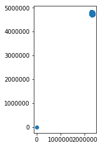

```python
strutture_geo.plot()
```

### Abbiamo visto che molti record non possiedono i campi COORDX e COORDY valorizzati.

Per evitare rappresentazioni che includono questi valori insignificanti ed errati,

attribuiamo un valore scelto a caso di localizzato appena fuori Italia (1956886, 5128102)

```python
strutture_geo.COORDX.isnull().sum()
```

```
1564
```

```python
strutture_geo.COORDY.isnull().sum()
```

```
1564
```

```python
#valorizzi i campi con i valori di default
strutture_geo.COORDX.fillna(1956886, inplace=True)
strutture_geo.COORDY.fillna(5128102, inplace=True)
#ricreo la colonna geometry
strutture_geo['geometry'] = list(zip(strutture_geo.COORDX, strutture_geo.COORDY))
strutture_geo['geometry'] = strutture_geo['geometry'].apply(Point)
```

### Disegniamo la mappa delle regioni d'Italia

Puoi scaricare i file geografici da ISTAT a questo link

[BASI TERRITORIALI E VARIABILI CENSUARIE](https://www.istat.it/it/archivio/104317)

Per comodità trovi il file "ISTAT_regioni.geojson" con le regioni italiane. nella cartella ./data

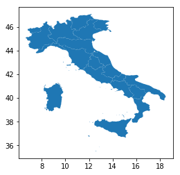

```python
italia = gpd.read_file("./data/ISTAT_regioni.geojson")
italia.plot()
```

```python
print (italia.crs)
```

```
{'towgs84': '0,0,0,0,0,0,0', 'ellps': 'WGS84', 'no_defs': True, 'proj': 'longlat'}
```

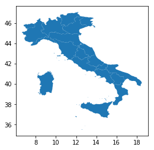

```python
italia.crs = {'init': 'epsg:3004'}
italia.plot()
```

```
(-118679.30227696239,
 2492262.2496469626,
 -256405.25490846235,
 5384507.2549084621)
```

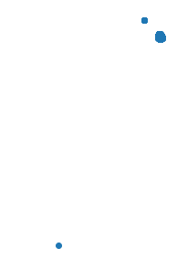

```python
#primo layer
ax = italia.plot(color='red',  edgecolor='white', figsize=(15,5))
#secondo layer
strutture_geo.plot(ax=ax)
ax.axis('off')
```

Adesso possiamo convertire così in quella richiesta ovvero WGS84

```python
strutture_geo = strutture_geo.to_crs({'init': 'epsg:4326'})
```

### Creiamo le due nuove colonne Latitudine e Longitudine

```python
strutture_geo["Longitudine"]= strutture_geo.geometry.x

strutture_geo["Latitudine"]= strutture_geo.geometry.y
```

```python
strutture_geo
```

|  | _id | ID | APT | COMUNE_CODICE | COMUNE | DENOMINAZIONE | TIPOLOGIA | CATEGORIA | INDIRIZZO | FRAZIONE | ... | WEB | EMAIL | COORDX | COORDY | TOTALE_UNITA | TOTALE_LETTI | TOTALE_BAGNI | geometry | Longitudine | Latitudine |
| --- | --- | --- | --- | --- | --- | --- | --- | --- | --- | --- | --- | --- | --- | --- | --- | --- | --- | --- | --- | --- | --- |
| 0 | 1 | 4945 | 2 | 54001 | ASSISI | OSTELLO FONTEMAGGIO | Ostello della gioventu' | Ostello della gioventu' | Via Eremo delle Carceri 24 | NaN | ... | www.fontemaggio.it | info@fontemaggio.it | 2327078.83 | 4770870.82 | 16 | 74 | 17 | POINT (12.6305683356952 43.06590420304492) | 12.63 | 43.07 |
| 1 | 2 | 17481 | 2 | 54001 | ASSISI | A CASA DELLE FATE di Cannelli Lorena | Bed & Breakfast | Bed & Breakfast | Via Metastasio 24 | NaN | ... | www.casalefate.it | info@casalefate.it | 1956886.00 | 5128102.00 | 2 | 4 | 2 | POINT (7.717248099961814 46.07370818661776) | 7.72 | 46.07 |
| 2 | 3 | 18660 | 2 | 54001 | ASSISI | A CASA MODESTINI di Vignoli Francesca | Bed & Breakfast | Bed & Breakfast | Via San Paolo 38 | NaN | ... | NaN | casamodestini@gmail.com | 1956886.00 | 5128102.00 | 1 | 3 | 1 | POINT (7.717248099961814 46.07370818661776) | 7.72 | 46.07 |
| 3 | 4 | 18126 | 2 | 54001 | ASSISI | A CASA TUA di Mantovani Anna | Bed & Breakfast | Bed & Breakfast | Via Piaggia San Pietro 9 | NaN | ... | NaN | info.acasatua@yahoo.it | 1956886.00 | 5128102.00 | 2 | 3 | 2 | POINT (7.717248099961814 46.07370818661776) | 7.72 | 46.07 |
| 4 | 5 | 13437 | 2 | 54001 | ASSISI | ADALGISA di Sensi Adalgisa | Bed & Breakfast | Bed & Breakfast | Via Lorenzo Perosi 33 | NaN | ... | NaN | agricola@nizzi.com | 2326766.01 | 4771047.31 | 1 | 2 | 1 | POINT (12.62666844451489 43.06741250076421) | 12.63 | 43.07 |
| 5 | 6 | 9260 | 2 | 54001 | ASSISI | AGORA' | Centro soggiorno studi | Centro soggiorno studi | Voc. Le Case 42 | SANTA MARIA DI LIGNANO | ... | NaN | assisiresort1@gmail.com | 2333097.48 | 4777327.43 | 20 | 35 | 20 | POINT (12.70225400365137 43.12550400132024) | 12.70 | 43.13 |
| 6 | 7 | 4948 | 2 | 54001 | ASSISI | AGRICOLA NIZZI | Agriturismo | 4 spighe | Costa di Trex 65 | COSTA DI TREX | ... | www.nizzi.com | agricola@nizzi.com | 2329234.54 | 4774594.87 | 6 | 28 | 6 | POINT (12.65574354561731 43.09995534338088) | 12.66 | 43.10 |
| 7 | 8 | 9392 | 2 | 54001 | ASSISI | AGRITURISMO CASA NOCCHIA TOR DEI MAMMONI | Agriturismo | 2 spighe | Costa di Trex 7 | COSTA DI TREX | ... | www.agriturismocasanocchia.it | info@agriturismocasanocchia.it | 2330306.72 | 4773159.98 | 4 | 10 | 4 | POINT (12.66939782185573 43.08731437716615) | 12.67 | 43.09 |
| 8 | 9 | 4991 | 2 | 54001 | ASSISI | AGRITURISMO CASA NUOVA | Agriturismo | 2 spighe | Pian della Pieve 55 | NaN | ... | www.agriturismocasanuova.it | info@agriturismocasanuova.it | 2329929.06 | 4775384.03 | 5 | 10 | 5 | POINT (12.66400078884869 43.10723012486224) | 12.66 | 43.11 |
| 9 | 10 | 5048 | 2 | 54001 | ASSISI | AGRITURISMO COL CACIONE | Agriturismo | 3 spighe | Costa di Trex | COSTA DI TREX | ... | www.agriturismocolcacione.it | colcacione@gmail.com | 2330886.55 | 4773295.99 | 6 | 13 | 6 | POINT (12.67646947729053 43.08868293379675) | 12.68 | 43.09 |
| 10 | 11 | 17160 | 2 | 54001 | ASSISI | AGRITURISMO DOLCE SENTIRE | Agriturismo | 2 spighe | Loc.Catecuccio 72 | PORZIANO | ... | www.agriturismodolcesentireassisi.it | info@agriturismodolcesentireassisi.it | 1956886.00 | 5128102.00 | 4 | 10 | 4 | POINT (7.717248099961814 46.07370818661776) | 7.72 | 46.07 |
| 11 | 12 | 5018 | 2 | 54001 | ASSISI | AGRITURISMO IL CASTELLO | Agriturismo | 4 spighe | Costa di Trex 25 | COSTA DI TREX | ... | www.agriturismoilcastello.com | info@agriturismoilcastello.com | 2329870.60 | 4773312.45 | 9 | 18 | 9 | POINT (12.66399201878933 43.0885769408284) | 12.66 | 43.09 |
| 12 | 13 | 4975 | 2 | 54001 | ASSISI | AGRITURISMO IL GIRASOLE | Agriturismo | 2 spighe | Via Campiglione 2 | NaN | ... | www.agriturismoilgirasole.net | info@agriturismoilgirasole.net | 2321257.34 | 4772124.77 | 5 | 10 | 5 | POINT (12.55868723663537 43.0756832200942) | 12.56 | 43.08 |
| 13 | 14 | 5073 | 2 | 54001 | ASSISI | AGRITURISMO IL GROTTINO | Agriturismo | 2 spighe | Via Campiglione 26 | NaN | ... | NaN | agri.grottino@gmail.com | 2321257.34 | 4772124.77 | 6 | 10 | 4 | POINT (12.55868723663537 43.0756832200942) | 12.56 | 43.08 |
| 14 | 15 | 5074 | 2 | 54001 | ASSISI | AGRITURISMO IL PODERE | Agriturismo | 5 spighe | Via Casa Madonna 14 | PETRIGNANO | ... | www.agriturismoilpodere.com | agriturismoilpodereassisi@gmail.com | 2319532.99 | 4775286.41 | 5 | 10 | 5 | POINT (12.53638500372325 43.10367300131389) | 12.54 | 43.10 |
| 15 | 16 | 5017 | 2 | 54001 | ASSISI | AGRITURISMO LA CANTINA | Agriturismo | 2 spighe | Via Campiglione,22 e Voc. S.Martino Via Vaiano... | NaN | ... | www.agriturismolacantina.it | agri.lacantina@alice.it | 2322844.99 | 4772253.12 | 9 | 23 | 11 | POINT (12.57812607545351 43.07725223632993) | 12.58 | 43.08 |
| 16 | 17 | 6646 | 2 | 54001 | ASSISI | AGRITURISMO LA MORA | Agriturismo | 3 spighe | Via Fonte Citerna 7 | SANTA MARIA DEGLI ANGELI | ... | www.agriturismolamora.com | agriturismolamora@gmail.com | 2319089.32 | 4776785.14 | 11 | 29 | 10 | POINT (12.53039537734651 43.11703865025989) | 12.53 | 43.12 |
| 17 | 18 | 18538 | 2 | 54001 | ASSISI | AGRITURISMO LA PALAZZETTA DI ASSISI | Agriturismo | 2 spighe | Via della Palazzetta | STERPETO | ... | www.agriturismolapalazzetta.com | info@agriturismolapalazzetta.com | 1956886.00 | 5128102.00 | 6 | 19 | 7 | POINT (7.717248099961814 46.07370818661776) | 7.72 | 46.07 |
| 18 | 19 | 4976 | 2 | 54001 | ASSISI | AGRITURISMO LA PANORAMICA | Agriturismo | 2 spighe | Via Campiglione 6 | NaN | ... | www.agriturismolapanoramica.it | info@agriturismolapanoramica.it | 2321257.34 | 4772124.77 | 8 | 20 | 9 | POINT (12.55868723663537 43.0756832200942) | 12.56 | 43.08 |
| 19 | 20 | 4905 | 2 | 54001 | ASSISI | AGRITURISMO LA PIAGGIA | Agriturismo | 2 spighe | Viale Giovanna di Savoia 3 | NaN | ... | www.lapiaggia.it | info@lapiaggia.it | 2324937.76 | 4771743.07 | 6 | 12 | 6 | POINT (12.60398969362102 43.07320437089242) | 12.60 | 43.07 |
| 20 | 21 | 6643 | 2 | 54001 | ASSISI | AGRITURISMO LA ROCCA | Agriturismo | 4 spighe | Rocca Sant' Angelo | ROCCA SANT'ANGELO | ... | www.agristar.it | info@agristar.it | 2320907.10 | 4778015.62 | 5 | 12 | 5 | POINT (12.55227704831001 43.12858858765693) | 12.55 | 43.13 |
| 21 | 22 | 14547 | 2 | 54001 | ASSISI | AGRITURISMO LE CASE | Agriturismo | 3 spighe | Via Sanat Maria di Lignano - Voc. Le Case 42 | SANTA MARIA DI LIGNANO | ... | www.lecase.biz | assisiresort1@gmail.com | 2333097.48 | 4777327.43 | 20 | 30 | 19 | POINT (12.70225400365137 43.12550400132024) | 12.70 | 43.13 |
| 22 | 23 | 18218 | 2 | 54001 | ASSISI | AGRITURISMO LE SORGENTI | Agriturismo | 3 spighe | Loc. Paradiso 40 | NaN | ... | NaN | mar.stoppini@gmail.com | 1956886.00 | 5128102.00 | 3 | 10 | 3 | POINT (7.717248099961814 46.07370818661776) | 7.72 | 46.07 |
| 23 | 24 | 5031 | 2 | 54001 | ASSISI | AGRITURISMO LONGETTI | Agriturismo | 4 spighe | Via Biagiano 35 | NaN | ... | www.agriturismolongetti.com | webmaster@agriturismolongetti.com | 2324371.22 | 4774723.95 | 9 | 15 | 9 | POINT (12.59598765889141 43.09987703079015) | 12.60 | 43.10 |
| 24 | 25 | 16622 | 2 | 54001 | ASSISI | AGRITURISMO PONTE ROSSO | Agriturismo | 1 spiga | Via Tescio 6 | SANTA MARIA DEGLI ANGELI | ... | NaN | info@assisium.com | 1956886.00 | 5128102.00 | 1 | 2 | 1 | POINT (7.717248099961814 46.07370818661776) | 7.72 | 46.07 |
| 25 | 26 | 4897 | 2 | 54001 | ASSISI | AGRITURISMO SIENA | Agriturismo | 2 spighe | Via Della Pescara 11 | NaN | ... | NaN | NaN | 2326029.62 | 4771374.35 | 4 | 9 | 4 | POINT (12.61751800363275 43.07016700134225) | 12.62 | 43.07 |
| 26 | 27 | 9925 | 2 | 54001 | ASSISI | AGRITURISMO SOLELUNA | Agriturismo | 1 spiga | Costa di Trex 54 | COSTA DI TREX | ... | www.agriturismosoleluna.it | info@agriturismosoleluna.it | 2330640.27 | 4773009.24 | 6 | 23 | 7 | POINT (12.67354377739211 43.08604140344851) | 12.67 | 43.09 |
| 27 | 28 | 18324 | 2 | 54001 | ASSISI | AL CASALE LA GERLA di Amicarelli Sara | Bed & Breakfast | Bed & Breakfast | Via Madre Terra 21 | NaN | ... | NaN | alcasalelagerla@libero.it | 1956886.00 | 5128102.00 | 3 | 7 | 3 | POINT (7.717248099961814 46.07370818661776) | 7.72 | 46.07 |
| 28 | 29 | 13537 | 2 | 54001 | ASSISI | AL CASALINO di Caldari Gabriele | Bed & Breakfast | Bed & Breakfast | Via San Rufino 2 | NaN | ... | www.alcasalino.it | alcasalino@alice.it | 2325880.82 | 4771475.66 | 1 | 2 | 1 | POINT (12.61565656134315 43.07104042792336) | 12.62 | 43.07 |
| 29 | 30 | 9653 | 2 | 54001 | ASSISI | AL PIAN D'ASSISI di Alessandretti Simone | Bed & Breakfast | Bed & Breakfast | Via San Martino 14 | NaN | ... | www.alpiandassisi.it | info@alpiandassisi.it | 2326029.62 | 4771374.35 | 4 | 7 | 4 | POINT (12.61751800363275 43.07016700134225) | 12.62 | 43.07 |
| ... | ... | ... | ... | ... | ... | ... | ... | ... | ... | ... | ... | ... | ... | ... | ... | ... | ... | ... | ... | ... | ... |
| 4069 | 4070 | 8878 | 11 | 55032 | TERNI | PENNA ROSSA RANCH | Bed & Breakfast | Bed & Breakfast | Strada del Nocione 19 | SAN LIBERATORE | ... | www.pennarossaranch.it | penna.rossa.ranch.bordoni@gmail.com | 2331629.09 | 4715943.45 | 2 | 6 | 2 | POINT (12.7047720035619 42.57281600136411) | 12.70 | 42.57 |
| 4070 | 4071 | 8051 | 11 | 55032 | TERNI | PIEDIMONTE | Agriturismo | 1 spiga | Str. di S.Clemente 47 | NaN | ... | NaN | susanna.santarelli@tiscali.it | 2327076.99 | 4717788.59 | 1 | 8 | 3 | POINT (12.64872953340789 42.58829431694642) | 12.65 | 42.59 |
| 4071 | 4072 | 17925 | 11 | 55032 | TERNI | PISTELLI | Agriturismo | 1 spiga | Str. di Santa Maria Maddalena 24/E | NaN | ... | NaN | info@frantoiopistelli.it | 1956886.00 | 5128102.00 | 5 | 9 | 5 | POINT (7.717248099961814 46.07370818661776) | 7.72 | 46.07 |
| 4072 | 4073 | 10227 | 11 | 55032 | TERNI | RESIDENCE BIZZONI | Albergo | 3 stelle | V.le Carducci 10 | NaN | ... | www.residencebizzoni.it | info@residencebizzoni.it | 2326429.98 | 4714911.46 | 14 | 36 | 16 | POINT (12.64182700355459 42.56224400134203) | 12.64 | 42.56 |
| 4073 | 4074 | 14219 | 11 | 55032 | TERNI | RESIDENCE CARDINALE ALBORNOZ | Case e appartamenti per vacanze | Case e appartamenti per vacanze | Via dell'Ara Marina 3 | PIEDILUCO | ... | NaN | residencealbornoz@tiscali.it | 2337616.57 | 4711848.04 | 7 | 14 | 7 | POINT (12.77897778349733 42.53740000138298) | 12.78 | 42.54 |
| 4074 | 4075 | 18203 | 11 | 55032 | TERNI | RESIDENCE DIAMANTE ROSSO | Case e appartamenti per vacanze | Case e appartamenti per vacanze | Via Don Luigi Sturzo 9 | NaN | ... | www.residencediamanterosso.it | info@residencediamanterosso.it | 1956886.00 | 5128102.00 | 25 | 68 | 25 | POINT (7.717248099961814 46.07370818661776) | 7.72 | 46.07 |
| 4075 | 4076 | 18889 | 11 | 55032 | TERNI | RESIDENCE VIVIVERDE | Case e appartamenti per vacanze | Case e appartamenti per vacanze | Via Angelo Rapaccioli 1 | NaN | ... | www.residenceviviverde.it | viviverdesrl@pec.it;info@residenceviviverde.it | 1956886.00 | 5128102.00 | 8 | 25 | 8 | POINT (7.717248099961814 46.07370818661776) | 7.72 | 46.07 |
| 4076 | 4077 | 17073 | 11 | 55032 | TERNI | RESIDENZA CERQUETO | Ostello della gioventu' | Ostello della gioventu' | Via del Tordo 69-71 | NaN | ... | www.residenzacerqueto.it | nardiarch@tiscali.it | 1956886.00 | 5128102.00 | 14 | 25 | 14 | POINT (7.717248099961814 46.07370818661776) | 7.72 | 46.07 |
| 4077 | 4078 | 18952 | 11 | 55032 | TERNI | RESIDENZA GARIBALDI | Affittacamere | Affittacamere | Vico dei Tintori 9 | NaN | ... | NaN | serenazampolini@gmail.com | 1956886.00 | 5128102.00 | 2 | 4 | 2 | POINT (7.717248099961814 46.07370818661776) | 7.72 | 46.07 |
| 4078 | 4079 | 18447 | 11 | 55032 | TERNI | ROSSIEROSSI | Bed & Breakfast | Bed & Breakfast | Via Campofregoso 15/A | NaN | ... | NaN | rossierossibedandbreakfast@gmail.com | 1956886.00 | 5128102.00 | 3 | 6 | 2 | POINT (7.717248099961814 46.07370818661776) | 7.72 | 46.07 |
| 4079 | 4080 | 17915 | 11 | 55032 | TERNI | VALLE DEGLI ULIVI | Bed & Breakfast | Bed & Breakfast | Str. di Collescipoli 173 | COLLESCIPOLI | ... | NaN | valledegliuliviterni@gmail.com | 1956886.00 | 5128102.00 | 2 | 4 | 2 | POINT (7.717248099961814 46.07370818661776) | 7.72 | 46.07 |
| 4080 | 4081 | 14407 | 11 | 55032 | TERNI | VENTO TRA GLI ULIVI | Bed & Breakfast | Bed & Breakfast | Voc. San Bartolomeo 63 | NaN | ... | NaN | info@ventotragliulivi.com | 2330496.66 | 4717644.47 | 3 | 6 | 3 | POINT (12.69042000355787 42.5878450014183) | 12.69 | 42.59 |
| 4081 | 4082 | 19673 | 11 | 55032 | TERNI | VILLA FLORIO | Affittacamere | Affittacamere | VIA MOLA DI BERNARDO 119 | NaN | ... | NaN | eugen.mano30@gmail.com | 1956886.00 | 5128102.00 | 1 | 2 | 1 | POINT (7.717248099961814 46.07370818661776) | 7.72 | 46.07 |
| 4082 | 4083 | 17287 | 11 | 55032 | TERNI | VILLA LAURA RESIDENCE | Case e appartamenti per vacanze | Case e appartamenti per vacanze | Str. di Cospea 50 | NaN | ... | www.villalauraresidence.it | info@villalauraresidence.it | 1956886.00 | 5128102.00 | 5 | 25 | 5 | POINT (7.717248099961814 46.07370818661776) | 7.72 | 46.07 |
| 4083 | 4084 | 14149 | 11 | 55032 | TERNI | VILLA MAFALDA | Bed & Breakfast | Bed & Breakfast | Str. di Collescipoli 327 | COLLESCIPOLI | ... | NaN | infovillamafalda@alice.it | 2324698.05 | 4712171.48 | 3 | 6 | 2 | POINT (12.6216830035774 42.53715400137509) | 12.62 | 42.54 |
| 4084 | 4085 | 18742 | 11 | 55032 | TERNI | VILLA MARIANI | Affittacamere | Affittacamere | Strada di Perticara 38 | NaN | ... | NaN | lallolucia06@libero.it | 1956886.00 | 5128102.00 | 2 | 5 | 2 | POINT (7.717248099961814 46.07370818661776) | 7.72 | 46.07 |
| 4085 | 4086 | 9624 | 11 | 55032 | TERNI | VILLA SABATINI | Bed & Breakfast | Bed & Breakfast | Via Faggeti 45 | MARMORE | ... | NaN | villasabatini_bb@yahoo.it | 2332529.27 | 4713161.40 | 3 | 8 | 3 | POINT (12.71664500357453 42.54800100141745) | 12.72 | 42.55 |
| 4086 | 4087 | 17375 | 1 | 55033 | AVIGLIANO UMBRO | AGRITURISMO IL MANNELLO | Agriturismo | Agriturismo | Strada del Mannello | NaN | ... | www.agriturismoilmannello.eu | info@agriturismoilmannello.eu | 1956886.00 | 5128102.00 | 1 | 8 | 4 | POINT (7.717248099961814 46.07370818661776) | 7.72 | 46.07 |
| 4087 | 4088 | 19407 | 1 | 55033 | AVIGLIANO UMBRO | AGRITURISMO LA SELVA | Agriturismo | Agriturismo | Voc. Selva s.n.c. | NaN | ... | NaN | mariocarita@virgilio.it | 1956886.00 | 5128102.00 | 1 | 4 | 1 | POINT (7.717248099961814 46.07370818661776) | 7.72 | 46.07 |
| 4088 | 4089 | 6707 | 1 | 55033 | AVIGLIANO UMBRO | AGRITURISMO PIANO GRANDE | Agriturismo | Agriturismo | Via Sant'Egidio 44 | NaN | ... | NaN | agriturismopianogrande@virgilio.it | 2308997.53 | 4725760.50 | 6 | 20 | 9 | POINT (12.42564494725172 42.65528091316298) | 12.43 | 42.66 |
| 4089 | 4090 | 17920 | 1 | 55033 | AVIGLIANO UMBRO | CASTELLO DI SISMANO | Residenza d'epoca | Residenza d'epoca | Via Corsini 12 | SISMANO | ... | www.sismano.com | info@sismano.com | 1956886.00 | 5128102.00 | 5 | 10 | 5 | POINT (7.717248099961814 46.07370818661776) | 7.72 | 46.07 |
| 4090 | 4091 | 7757 | 1 | 55033 | AVIGLIANO UMBRO | HOTEL LA TENUTA DEI CICLAMINI | Albergo | 3 stelle | Localita' Casapancallo 3 | TOSCOLANO | ... | www.iciclamini.it | daniela@cetmusic.it; | 2302835.34 | 4726356.19 | 58 | 145 | 64 | POINT (12.35031500367986 42.6589260013397) | 12.35 | 42.66 |
| 4091 | 4092 | 15110 | 1 | 55033 | AVIGLIANO UMBRO | IL CALLAUZZO | Case e appartamenti per vacanze | Case e appartamenti per vacanze | Vocabolo Callauzzo 48-49A | SISMANO | ... | NaN | NaN | 2310454.27 | 4729404.62 | 3 | 15 | 4 | POINT (12.4420550037277 42.68846300141228) | 12.44 | 42.69 |
| 4092 | 4093 | 15704 | 1 | 55033 | AVIGLIANO UMBRO | L'ACQUAIO | Case e appartamenti per vacanze | Case e appartamenti per vacanze | Localita' Macchia dei Frati | NaN | ... | NaN | daniela@cetmusic.it | 2309140.02 | 4725331.00 | 3 | 10 | 3 | POINT (12.42754100368852 42.65145600134511) | 12.43 | 42.65 |
| 4093 | 4094 | 15399 | 1 | 55033 | AVIGLIANO UMBRO | LA CRISTALLA | Agriturismo | Agriturismo | Vocabolo Cristalla 6 | SANTA RESTITUTA | ... | NaN | NaN | 2302344.15 | 4724821.89 | 1 | 4 | 3 | POINT (12.34491600367964 42.64498500134088) | 12.34 | 42.64 |
| 4094 | 4095 | 15108 | 1 | 55033 | AVIGLIANO UMBRO | LA FORTEZZA | Agriturismo | Agriturismo | Localita' Fortezza Alta 27 | DUNAROBBA | ... | www.lafortezzaalta.com | info@lafortezzaalta.it | 2309681.72 | 4727686.78 | 4 | 19 | 5 | POINT (12.43327076756797 42.67279772223081) | 12.43 | 42.67 |
| 4095 | 4096 | 18295 | 1 | 55033 | AVIGLIANO UMBRO | LA LANTERNA | Affittacamere | Affittacamere | Via Giacomo Matteotti 86 | NaN | ... | NaN | marsilianipietro@gmail.com | 1956886.00 | 5128102.00 | 6 | 12 | 6 | POINT (7.717248099961814 46.07370818661776) | 7.72 | 46.07 |
| 4096 | 4097 | 18296 | 1 | 55033 | AVIGLIANO UMBRO | LA LANTERNA B & B | Bed & Breakfast | Bed & Breakfast | Via Giacomo Matteotti 86 | NaN | ... | NaN | marsilianipietro@gmail.com | 1956886.00 | 5128102.00 | 3 | 8 | 3 | POINT (7.717248099961814 46.07370818661776) | 7.72 | 46.07 |
| 4097 | 4098 | 15333 | 1 | 55033 | AVIGLIANO UMBRO | LE BANDITE | Affittacamere | Affittacamere | Vocabolo Suffragio 5 | DUNAROBBA | ... | NaN | lebandite@alice.it | 2310351.66 | 4727135.38 | 4 | 12 | 4 | POINT (12.44164200363892 42.66802000140996) | 12.44 | 42.67 |
| 4098 | 4099 | 15156 | 1 | 55033 | AVIGLIANO UMBRO | PIAN DELLE ROSE | Agriturismo | Agriturismo | Via Madonna delle Grazie 8 | NaN | ... | www.piandellerose.it | ciatticatozzi@alice.it; info@piandellerose.it | 2309111.96 | 4725307.06 | 3 | 10 | 3 | POINT (12.42720794785487 42.65123296621364) | 12.43 | 42.65 |

4099 rows × 25 columns

## Dataset "codifiche apt"

Difficile capire di cosa si tratta, immaginiamo che si tratti della decodifica del campo "APT" contenuto in "strutture"

[figure not shown]

```python
codifiche= pd.read_csv("http://dati.umbria.it/datastore/dump/917d5b95-6c27-4acd-9b8d-8b60e190c891")
```

```python
codifiche.shape
```

```
(12, 4)
```

```python
codifiche
```

|  | _id | CODICE | COD_ISTAT | DESCRIZIONE |
| --- | --- | --- | --- | --- |
| 0 | 1 | 1 | 553603 | AMERINO |
| 1 | 2 | 2 | 543102 | ASSISANO |
| 2 | 3 | 3 | 543603 | VALNERINA - CASCIA |
| 3 | 4 | 4 | 543309 | TRASIMENO |
| 4 | 5 | 5 | 543601 | ALTA VALLE DEL TEVERE |
| 5 | 6 | 6 | 543604 | FOLIGNATE - NOCERA UMBRA |
| 6 | 7 | 7 | 543105 | EUGUBINO - ALTOCHIASCIO |
| 7 | 8 | 8 | 553101 | ORVIETANO |
| 8 | 9 | 9 | 541106 | PERUGINO |
| 9 | 10 | 10 | 543107 | SPOLETINO |
| 10 | 11 | 11 | 551602 | TERNANO |
| 11 | 12 | 12 | 543608 | TUDERTE |

### Confrontiamo i campi "codifiche"

[figure not shown]

### Uniamo le info deldataset *Strutture* e del dataset *Codifiche*

Attraverso il comando "merge" offerto dalla libreria Pandas, in modo da avere un unico dataframe contenente anche le decodifiche/informazioni racchiuse nel dataset delle codifiche.

[Consulta la documentazione](https://pandas.pydata.org/pandas-docs/stable/generated/pandas.DataFrame.merge.html)

```python
strutture_codifiche = strutture_geo.merge(codifiche, how='inner',left_on='APT', right_on='CODICE')
```

```python
strutture_codifiche.head(3).T
```

|  | 0 | 1 | 2 |
| --- | --- | --- | --- |
| _id_x | 1 | 2 | 3 |
| ID | 4945 | 17481 | 18660 |
| APT | 2 | 2 | 2 |
| COMUNE_CODICE | 54001 | 54001 | 54001 |
| COMUNE | ASSISI | ASSISI | ASSISI |
| DENOMINAZIONE | OSTELLO FONTEMAGGIO | A CASA DELLE FATE di Cannelli Lorena | A CASA MODESTINI di Vignoli Francesca |
| TIPOLOGIA | Ostello della gioventu' | Bed & Breakfast | Bed & Breakfast |
| CATEGORIA | Ostello della gioventu' | Bed & Breakfast | Bed & Breakfast |
| INDIRIZZO | Via Eremo delle Carceri 24 | Via Metastasio 24 | Via San Paolo 38 |
| FRAZIONE | NaN | NaN | NaN |
| CAP | 06081 | 06081 | 06081 |
| PROV | PG | PG | PG |
| TELEFONO | 075813636 | 075813739 | 3491930389 |
| TELEFONO2 | 075812317 | 075816413 | 075812252 |
| FAX | 075813749 | NaN | 1782219813 |
| WEB | www.fontemaggio.it | www.casalefate.it | NaN |
| EMAIL | info@fontemaggio.it | info@casalefate.it | casamodestini@gmail.com |
| COORDX | 2327078.83 | 1956886.00 | 1956886.00 |
| COORDY | 4770870.82 | 5128102.00 | 5128102.00 |
| TOTALE_UNITA | 16 | 2 | 1 |
| TOTALE_LETTI | 74 | 4 | 3 |
| TOTALE_BAGNI | 17 | 2 | 1 |
| geometry | POINT (12.6305683356952 43.06590420304492) | POINT (7.717248099961814 46.07370818661776) | POINT (7.717248099961814 46.07370818661776) |
| Longitudine | 12.63 | 7.72 | 7.72 |
| Latitudine | 43.07 | 46.07 | 46.07 |
| _id_y | 2 | 2 | 2 |
| CODICE | 2 | 2 | 2 |
| COD_ISTAT | 543102 | 543102 | 543102 |
| DESCRIZIONE | ASSISANO | ASSISANO | ASSISANO |

### Check su dataframe finale *strutture_codifiche*

Il numero di righe del dataframe risultante deve avere lo stesso numero di righe di quello iniziale a patto che ci sia integrità tra la tabella dei fatti (strutture) e quella della dimensione (codifiche)

```python
strutture_geo.shape
```

```
(4099, 25)
```

```python
codifiche.shape
```

```
(12, 4)
```

```python
strutture_codifiche.shape
```

```
(4099, 29)
```

### Eliminiamo i campi non necessari

C'è una duplicazione di informazione: i campi "APT" e "CODICE" possiedono la stessa info.

Possiamo quindi eliminare il campo "codice" e anche i campi "_id_y" e "_id_x" che sono identificativi di cui non conosciamo l'utilità.

Inoltre possiamo eliminare i campi geografici originali mantenere solo le nuove colonne "Latitudine" e "Longitudine".

Nota: inplace=True

```python
strutture_codifiche.drop(['_id_y','_id_x','CODICE','ID', 'COORDX','COORDY'], axis=1, inplace=True)
```

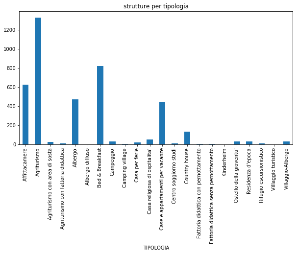

```python
strutture_codifiche.groupby(strutture_codifiche.TIPOLOGIA).size().plot.bar(title="strutture per tipologia",figsize=(10,5))
```

### Salviamo il dataset finale

Per caricare sulla piattaforma DAF ho bisogno di un sample del dataset e dell'inter dataset in formato csv. La libreria Pandas ci permette di farlo agilmente in un unico comando:

In particolare utilizziamo il comando **nome_dataframe.to_csv()**

Si possono specificare molte opzioni ad esempio sul *separatore* da usare, il tipo di *encoding*...

Il parametro **index=False** fa sì che non venga esportata anche la prima colonna contenente l'indice del dataframe.

[Consulta la documentazione](https://pandas.pydata.org/pandas-docs/stable/generated/pandas.DataFrame.to_csv.html)

```python
strutture_codifiche.columns
```

```
Index(['APT', 'COMUNE_CODICE', 'COMUNE', 'DENOMINAZIONE', 'TIPOLOGIA',
       'CATEGORIA', 'INDIRIZZO', 'FRAZIONE', 'CAP', 'PROV', 'TELEFONO',
       'TELEFONO2', 'FAX', 'WEB', 'EMAIL', 'TOTALE_UNITA', 'TOTALE_LETTI',
       'TOTALE_BAGNI', 'geometry', 'Longitudine', 'Latitudine', 'COD_ISTAT',
       'DESCRIZIONE'],
      dtype='object')
```

```python
strutture_codifiche.to_csv("./data/strutture_umbria.csv", sep=';',index=False)
```

### DAF metadatazione

Per poter caricare il dataset nella piattforma DAF è necessario prima metadatare il dataset stesso utilizzando un sample rappresentativo.

E' necessario che l'utenza utilizzata appartenga al gruppo *daf_editor*.

[Login DAF - Accedi](https://dataportal-private.daf.teamdigitale.it/#/login)

[figure not shown]

### DAF invio dataset con SFTP

Dopo aver metadato il dataset, è necessario inviare nella cartella specificata nella scheda informativa il dataset completo.

Puoi utilizzare comodamente alcuni tool come [Filezilla](https://filezilla-project.org/) oppure farlo attraverso alcune righe di codice.

Dovrai inserire il tuo utente, la tua password e autenticarti via SFTP a daf.teamdigitale.it (porta 22)

Importiamo il modulo **pysftp** che ci permette di effettuare il trasferimento via SFTP

[Consulta la documentazione](http://pysftp.readthedocs.io/en/release_0.2.8/cookbook.html)

```python
import pysftp
```

```python
sftp_host = "daf.teamdigitale.it"
sftp_user = "user"
sftp_password = "secret"


local_path = "./data/strutture_umbria.csv"
sftp_path = "test/2"

cnopts = pysftp.CnOpts()
cnopts.hostkeys = None
cnopts.compression = True

with pysftp.Connection(host=sftp_host,
                       username=sftp_user,
                       password=sftp_password,
                       cnopts=cnopts) as sftp:
    sftp.chdir(sftp_path)
    sftp.put(local_path, confirm=True)
```

A questo punto, dopo aver atteso alcuni minuti, il tuo dataset verrà caricato e potrai monitorare lo status tramite la scheda del dataset.

Inoltre se hai deciso di renderlo pubblico, apparirà automaticamente sul portale [SaaS](https://umbria.daf.teamdigitale.it/).

Clicca su strumenti --> Superset per creare dei widget

[figure not shown]